# Pretransplant natural antibody levels identify a subset of deceased donor kidney transplant recipients that benefit from infliximab induction

### 9.3.2 Models

#### 9.3.2.1 Main effects models

**Open code**

```r
model_GFR_MDRD_3_MPL_BC_main <- run(
  expr = brm_multiple(
    GFR_MDRD_3 ~
      male_sex +
      I(rec_age - 50) +
      male_sex_donor +
      I(KDPI - 50) +
      I(CIT - 15) +
      I(HLA_MM - 5) +
      perfusion_event +
      infliximab +
      I(MPL_BC_log2 - 2),
    family = student(),
    data = data_imputed,
    prior = priors_main,
    backend = "cmdstanr",
    seed = 2025,
    cores = 4, chains = 4,
    iter = 2000, warmup = 1900,
    control = list(adapt_delta = 0.95)
  ),
  path = "gitignore/run/model_GFR_MDRD_3_MPL_BC_main",
  reuse = TRUE
)

summary(model_GFR_MDRD_3_MPL_BC_main, robust = TRUE)
## Warning: Parts of the model have not converged (some Rhats are > 1.05). Be
## careful when analysing the results! We recommend running more iterations and/or
## setting stronger priors.
##  Family: student
##   Links: mu = identity; sigma = identity; nu = identity
## Formula: GFR_MDRD_3 ~ male_sex + I(rec_age - 50) + male_sex_donor + I(KDPI - 50) + I(CIT - 15) + I(HLA_MM - 5) + perfusion_event + infliximab + I(MPL_BC_log2 - 2)
##    Data: data_imputed (Number of observations: 177)
##   Draws: 320 chains, each with iter = 2000; warmup = 1900; thin = 1;
##          total post-warmup draws = 32000
##
## Regression Coefficients:
##                 Estimate Est.Error l-95% CI u-95% CI Rhat Bulk_ESS Tail_ESS
## Intercept          53.98      4.12    45.84    62.07 1.01    17881    26136
## male_sex            1.39      3.25    -5.09     7.91 1.01    38469    28129
## Irec_ageM50         0.02      0.15    -0.28     0.32 1.01    38402    27141
## male_sex_donor      0.66      3.21    -5.57     6.94 1.01    37506    27707
## IKDPIM50           -0.24      0.08    -0.39    -0.08 1.01    36437    27843
## ICITM15             0.31      0.22    -0.13     0.75 1.02    10533    25501
## IHLA_MMM5          -0.73      1.10    -2.89     1.43 1.06     3345    12707
## perfusion_event    -6.70      3.50   -13.61     0.23 1.06     3314    12070
## infliximab         -2.62      3.18    -8.94     3.67 1.01    37498    27533
## IMPL_BC_log2M2     -0.82      1.03    -2.82     1.23 1.01    36554    27952
##
## Further Distributional Parameters:
##       Estimate Est.Error l-95% CI u-95% CI Rhat Bulk_ESS Tail_ESS
## sigma    18.91      1.39    16.08    21.65 1.01    27313    23629
## nu       15.11      9.07     5.10    49.59 1.00    29833    26721
##
## Draws were sampled using sample(hmc). For each parameter, Bulk_ESS
## and Tail_ESS are effective sample size measures, and Rhat is the potential
## scale reduction factor on split chains (at convergence, Rhat = 1).
prior_summary(model_GFR_MDRD_3_MPL_BC_main)
##                          prior     class            coef group resp dpar nlpar
##                         (flat)         b
##    normal(0, 5.93437623501858)         b         ICITM15
##    normal(0, 29.2623385998383)         b       IHLA_MMM5
##    normal(0, 2.05566141844214)         b        IKDPIM50
##    normal(0, 27.0849589154158)         b  IMPL_BC_log2M2
##    normal(0, 84.6839516288788)         b      infliximab
##    normal(0, 4.03497355002315)         b     Irec_ageM50
##    normal(0, 84.6839516288788)         b        male_sex
##    normal(0, 84.6839516288788)         b  male_sex_donor
##    normal(0, 84.6839516288788)         b perfusion_event
##  normal(51.7227118644068, 200) Intercept
##                  gamma(2, 0.1)        nu
##          student_t(3, 0, 19.7)     sigma
##  lb ub  source
##        default
##           user
##           user
##           user
##           user
##           user
##           user
##           user
##           user
##           user
##           user
##   1    default
##   0    default

tr <- round(fixef(model_GFR_MDRD_3_MPL_BC_main, robust = TRUE)[-1, c(1,3,4)], 2)
colnames(tr)[1] <- 'Estimate'
kableExtra::kable(tr)
```

Table 21: Results from multivariable Bayesian robust regression models examining the main effects of predictors, including `infliximab` treatment and log2-transformed anti-cardiolipin IgM (`MPL_BC_log2`), on estimated glomerular filtration rate (eGFR), without interaction terms. `Estimate` represents the estimated change in eGFR per one-unit increase in the predictor. `Q2.5` and `Q97.5`: lower and upper bounds of the 95% credible interval, respectively.

|  | Estimate | Q2.5 | Q97.5 |
| --- | --- | --- | --- |
| male_sex | 1.39 | -5.09 | 7.91 |
| Irec_ageM50 | 0.02 | -0.28 | 0.32 |
| male_sex_donor | 0.66 | -5.57 | 6.94 |
| IKDPIM50 | -0.24 | -0.39 | -0.08 |
| ICITM15 | 0.31 | -0.13 | 0.75 |
| IHLA_MMM5 | -0.73 | -2.89 | 1.43 |
| perfusion_event | -6.70 | -13.61 | 0.23 |
| infliximab | -2.62 | -8.94 | 3.67 |
| IMPL_BC_log2M2 | -0.82 | -2.82 | 1.23 |

#### 9.3.2.2 Non-linear interaction model

**Open code**

```r
model_GFR_MDRD_3_MPL_BC_interaction_NL <- run(
  expr = brm_multiple(
    GFR_MDRD_3 ~
    male_sex +
    I(rec_age - 50) +
    male_sex_donor +
    I(KDPI - 50) +
    I(CIT - 15) +
    I(HLA_MM - 5) +
    perfusion_event +
    infliximab +
    s(I(MPL_BC_log2-2), bs = 'ps', k = 5) +
    s(I(MPL_BC_log2-2), by = infliximab, bs = 'ps', k = 5),
    family = student(),
    data = data_imputed,
    prior = priors_interaction_pnl,
    backend = "cmdstanr",
    seed = 2025,
    cores = 4, chains = 4,
    iter = 2000, warmup = 1900,
    control = list(adapt_delta = 0.95)
  ),
  path = "gitignore/run/model_GFR_MDRD_3_MPL_BC_interaction_NL",
  reuse = TRUE
)

summary(model_GFR_MDRD_3_MPL_BC_interaction_NL, robust = TRUE)
## Warning: Parts of the model have not converged (some Rhats are > 1.05). Be
## careful when analysing the results! We recommend running more iterations and/or
## setting stronger priors.
##  Family: student
##   Links: mu = identity; sigma = identity; nu = identity
## Formula: GFR_MDRD_3 ~ male_sex + I(rec_age - 50) + male_sex_donor + I(KDPI - 50) + I(CIT - 15) + I(HLA_MM - 5) + perfusion_event + infliximab + s(I(MPL_BC_log2 - 2), bs = "ps", k = 5) + s(I(MPL_BC_log2 - 2), by = infliximab, bs = "ps", k = 5)
##    Data: data_imputed (Number of observations: 177)
##   Draws: 320 chains, each with iter = 2000; warmup = 1900; thin = 1;
##          total post-warmup draws = 32000
##
## Smoothing Spline Hyperparameters:
##                                  Estimate Est.Error l-95% CI u-95% CI Rhat
## sds(sIMPL_BC_log2M2_1)               5.47      5.12     0.27    26.04 1.01
## sds(sIMPL_BC_log2M2infliximab_1)     3.93      3.68     0.18    18.57 1.01
##                                  Bulk_ESS Tail_ESS
## sds(sIMPL_BC_log2M2_1)              23473    17212
## sds(sIMPL_BC_log2M2infliximab_1)    30914    16767
##
## Regression Coefficients:
##                              Estimate Est.Error l-95% CI u-95% CI Rhat Bulk_ESS
## Intercept                       53.59      4.13    45.45    61.86 1.01    18394
## male_sex                         1.61      3.25    -4.83     8.03 1.01    45915
## Irec_ageM50                      0.02      0.15    -0.27     0.32 1.01    45146
## male_sex_donor                   0.23      3.16    -6.09     6.54 1.01    47794
## IKDPIM50                        -0.24      0.08    -0.39    -0.08 1.01    44970
## ICITM15                          0.31      0.22    -0.13     0.75 1.02    11127
## IHLA_MMM5                       -0.75      1.10    -2.96     1.40 1.06     3332
## perfusion_event                 -7.06      3.54   -13.99    -0.11 1.06     3438
## infliximab                      -0.02     81.30  -163.96   161.14 1.01    14172
## sIMPL_BC_log2M2_1               -6.36     11.82   -33.38    20.35 1.01    28050
## sIMPL_BC_log2M2:infliximab_1   -12.17     59.34  -129.21   106.48 1.01    14377
## sIMPL_BC_log2M2:infliximab_2     8.82     20.16   -30.85    48.72 1.01    14618
##                              Tail_ESS
## Intercept                       28686
## male_sex                        26098
## Irec_ageM50                     26443
## male_sex_donor                  26205
## IKDPIM50                        28413
## ICITM15                         27006
## IHLA_MMM5                       17384
## perfusion_event                 14352
## infliximab                      18654
## sIMPL_BC_log2M2_1               21919
## sIMPL_BC_log2M2:infliximab_1    19452
## sIMPL_BC_log2M2:infliximab_2    20303
##
## Further Distributional Parameters:
##       Estimate Est.Error l-95% CI u-95% CI Rhat Bulk_ESS Tail_ESS
## sigma    18.87      1.38    16.03    21.58 1.01    30872    23148
## nu       15.53      9.34     5.13    50.54 1.00    32611    27010
##
## Draws were sampled using sample(hmc). For each parameter, Bulk_ESS
## and Tail_ESS are effective sample size measures, and Rhat is the potential
## scale reduction factor on split chains (at convergence, Rhat = 1).
prior_summary(model_GFR_MDRD_3_MPL_BC_interaction_NL)
##                          prior     class
##                         (flat)         b
##    normal(0, 5.93437623501858)         b
##    normal(0, 29.2623385998383)         b
##    normal(0, 2.05566141844214)         b
##    normal(0, 84.6839516288788)         b
##    normal(0, 4.03497355002315)         b
##    normal(0, 84.6839516288788)         b
##    normal(0, 84.6839516288788)         b
##    normal(0, 84.6839516288788)         b
##                         (flat)         b
##                         (flat)         b
##                         (flat)         b
##  normal(51.7227118644068, 200) Intercept
##                  gamma(2, 0.1)        nu
##          student_t(3, 0, 19.7)       sds
##            student_t(3, 0, 12)       sds
##             student_t(3, 0, 6)       sds
##          student_t(3, 0, 19.7)     sigma
##                                                      coef group resp dpar nlpar
##
##                                                   ICITM15
##                                                 IHLA_MMM5
##                                                  IKDPIM50
##                                                infliximab
##                                               Irec_ageM50
##                                                  male_sex
##                                            male_sex_donor
##                                           perfusion_event
##                                         sIMPL_BC_log2M2_1
##                              sIMPL_BC_log2M2:infliximab_1
##                              sIMPL_BC_log2M2:infliximab_2
##
##
##
##                   s(I(MPL_BC_log2 - 2), bs = "ps", k = 5)
##  s(I(MPL_BC_log2 - 2), by = infliximab, bs = "ps", k = 5)
##
##  lb ub       source
##             default
##                user
##                user
##                user
##                user
##                user
##                user
##                user
##                user
##        (vectorized)
##        (vectorized)
##        (vectorized)
##                user
##   1         default
##   0         default
##   0            user
##   0            user
##   0         default


tr2 <- round(fixef(model_GFR_MDRD_3_MPL_BC_interaction_NL,
                   robust = TRUE)[-c(1,9:12), c(1,3,4)], 2)

antibody_seq <- quantile(data_model_priorImpute$MPL_BC_log2, probs = c(0.05, 0.95))

asl <- length(antibody_seq)
quant_dif <- antibody_seq[2] - antibody_seq[1]

data_prediction <- data.frame(
    male_sex = rep(mmale_sex, 2*length(antibody_seq)),
  `male_sex_donor` = rep(mmale_sex_donor, 2*length(antibody_seq)),
  `perfusion_event` = rep(mperfusion_event, 2*length(antibody_seq)),
  `infliximab` = c(rep(0, length(antibody_seq)), rep(1, length(antibody_seq))),
  `rec_age` = rep(mrec_age, 2*length(antibody_seq)),
  `KDPI` = rep(mKDPI, 2*length(antibody_seq)),
  `CIT` = rep(mCIT, 2*length(antibody_seq)),
  `HLA_MM` = rep(mHLA_MM, 2*length(antibody_seq)),
  `MPL_BC_log2` = c(antibody_seq, antibody_seq)
  )

tr <-  posterior_epred(
    model_GFR_MDRD_3_MPL_BC_interaction_NL,
    newdata = data_prediction)

prediction_ctrl <- tr[, c(1:asl)]
prediction_infliximab <- tr[, c((asl+1):(asl*2))]

## get Estimate for infliximab effect across antibody values
prediction <- (
  prediction_infliximab-
     prediction_ctrl
  ) %>% data.frame()
names(prediction) <- c('p05', 'p95')

infliximab_MPL_BC_log2_int <- quantile((prediction$p95 - prediction$p05)/scaling_unit,
         probs = c(0.5, 1/40, 39/40))

tr2 <- rbind(tr2, round(infliximab_MPL_BC_log2_int, 2))
row.names(tr2)[8] <- 'infliximab:MPL_BC_log2'
kableExtra::kable(tr2)
```

Table 22: Results from a multivariable Bayesian robust regression model incorporating a non-linear interaction between anti-cardiolipin IgM (`MPL_BC_log2`) and `infliximab` treatment on estimated glomerular filtration rate (eGFR), while accounting for other covariates. `Estimate` represents the estimated change in eGFR per one-unit increase in the predictor. The last row (`infliximab:MPL_BC_log2`) reports the difference in infliximab’s treatment effect at the 95th versus the 5th percentile of anti-cardiolipin IgM, quantifying the interaction effect. `Q2.5` and `Q97.5`: lower and upper bounds of the 95% credible interval, respectively.

|  | Estimate | Q2.5 | Q97.5 |
| --- | --- | --- | --- |
| male_sex | 1.61 | -4.83 | 8.03 |
| Irec_ageM50 | 0.02 | -0.27 | 0.32 |
| male_sex_donor | 0.23 | -6.09 | 6.54 |
| IKDPIM50 | -0.24 | -0.39 | -0.08 |
| ICITM15 | 0.31 | -0.13 | 0.75 |
| IHLA_MMM5 | -0.75 | -2.96 | 1.40 |
| perfusion_event | -7.06 | -13.99 | -0.11 |
| infliximab:MPL_BC_log2 | -17.91 | -37.96 | 1.85 |

### 9.3.3 Visualisation - penalized non-linear effect

Extract posterior draws

**Open code**

```r
antibody_perc <- quantile(data_model_priorImpute$MPL_BC_log2,
                           probs = c(0, 0.02, 0.05, 0.25, 0.5, 0.75, 0.95, 0.98, 1))

antibody_seq <- seq(antibody_perc[1],
                      antibody_perc[length(antibody_perc)],
                      length.out = 101)

## create prediction
data_prediction <- data.frame(
  male_sex = rep(mmale_sex, 2*length(antibody_seq)),
  `male_sex_donor` = rep(mmale_sex_donor, 2*length(antibody_seq)),
  `perfusion_event` = rep(mperfusion_event, 2*length(antibody_seq)),
  `infliximab` = c(rep(0, length(antibody_seq)), rep(1, length(antibody_seq))),
  `rec_age` = rep(mrec_age, 2*length(antibody_seq)),
  `KDPI` = rep(mKDPI, 2*length(antibody_seq)),
  `CIT` = rep(mCIT, 2*length(antibody_seq)),
  `HLA_MM` = rep(mHLA_MM, 2*length(antibody_seq)),
  `MPL_BC_log2` = c(antibody_seq, antibody_seq)
  )

prediction <- data.frame(
  posterior_epred(
    model_GFR_MDRD_3_MPL_BC_interaction_NL,
    newdata = data_prediction) %>% posterior_summary(
      robust = TRUE
      ) %>% data.frame() %>% select(-Est.Error),
  group = factor(if_else(data_prediction$infliximab == 1, 'infliximab', 'control')),
  MPL_BC_log2 = data_prediction$MPL_BC_log2)
```

Figure A

**Open code**

```r
cole <- c('#CD7006', '#0028F0')

fig_a <- prediction %>%
  mutate(group = factor(group, levels = c("infliximab", "control")),
         `Q2.5` = if_else(`Q2.5` < 0, 0, `Q2.5`)) %>%
  ggplot(aes(x = MPL_BC_log2, y = Estimate, col = group, fill = group)) +
  geom_line(aes(y = Estimate), linewidth = 1) +
  scale_y_continuous(limits = c(0, 125),
                     breaks = c(seq(0, 125, by = 25))) +

  geom_ribbon(aes(ymin = `Q2.5`, ymax = `Q97.5`),
               alpha = 0.4,  color = NA) +

  geom_point(data = data_model_priorImpute,
             aes(x = MPL_BC_log2, y = GFR_MDRD_3, col = group, fill = group)) +

  labs(x = expression(log[2]~"(aCL IgM ["*mu*"g/ml])"), y = "GFR (mL/min/1.73 m²)") +
  scale_color_manual(values = cole,
                       name = "group",
                       breaks = c('control', 'infliximab'),
                       labels = c('control', 'infliximab')) +

  scale_fill_manual(values = cole,
                       name = "group",
                       breaks = c('control', 'infliximab'),
                       labels = c('control', 'infliximab')) +

  facet_grid(rows = vars(group)) +

  theme(axis.text=element_text(size=10),
        axis.title=element_text(size=12),
        strip.text.x = element_text(size = 12),
        legend.position = "none") +

  geom_vline(xintercept = antibody_perc[3:7], linetype = 2,
                            color = "grey50", size = 0.3)
```

Figure B

**Open code**

```r
antibody_seq <- antibody_perc[c(3, 7)]
antibody_seq
##         5%        95%
## -0.3963058  4.5810923

data_prediction <- data.frame(
   male_sex = rep(mmale_sex, 2*length(antibody_seq)),
  `male_sex_donor` = rep(mmale_sex_donor, 2*length(antibody_seq)),
  `perfusion_event` = rep(mperfusion_event, 2*length(antibody_seq)),
  `infliximab` = c(rep(0, length(antibody_seq)), rep(1, length(antibody_seq))),
  `rec_age` = rep(mrec_age, 2*length(antibody_seq)),
  `KDPI` = rep(mKDPI, 2*length(antibody_seq)),
  `CIT` = rep(mCIT, 2*length(antibody_seq)),
  `HLA_MM` = rep(mHLA_MM, 2*length(antibody_seq)),
  `MPL_BC_log2` = c(antibody_seq, antibody_seq)
  )

tr <-  posterior_epred(
    model_GFR_MDRD_3_MPL_BC_interaction_NL,
    newdata = data_prediction)

tr_ctrl <- (tr[,c(ncol(tr)/2)] - tr[,c(1)])

tr_infliximab <- (tr[,c(ncol(tr))] - tr[,c(ncol(tr)/2)+1])

post_fix <- data.frame(
  b_MPL_BC_log2 = tr_ctrl,
  b_MPL_BC_log2_infliximab = tr_infliximab
)

tr <- post_fix %>%
  mutate(control = (b_MPL_BC_log2),
         infliximab = (b_MPL_BC_log2_infliximab)) %>%
  select(control, infliximab) %>%
  data.frame()

CIS <- sapply(
  tr,
  function(p) quantile(p, probs = c(1/40, 39/40, 0.5, 1e-3, 1-1e-3))
  ) %>%
  round(1)

CIS
##       control infliximab
## 2.5%     -9.3      -28.1
## 97.5%    18.9        1.5
## 50%       4.7      -13.2
## 0.1%    -17.8      -37.7
## 99.9%    27.1        9.4

xpos <- 39.2

fig_b <- tr %>%
  pivot_longer(values_to = 'value',
               cols = c('control', 'infliximab'),
               names_to = 'group') %>%
  ggplot(aes(x = value, y = group, fill = group)) +

  stat_halfeye(.width = c(0.95), slab_alpha=0.5,
               linewidth = 5,
               shape = 18,
               point_size = 5,
               normalize = "groups",
               p_limits = c(1e-3, 1-1e-3)) +

    labs(x = 'Effect of aCL IgM increase (p05 to p95) on eGFR',
         y = 'Treatment group') +

  scale_fill_manual(values = cole,
                       name = "Treatment group",
                       breaks = c('control', 'infliximab'),
                       labels = c('control', 'infliximab')) +

  scale_y_discrete(expand = expansion(add = 0.1)) +
  coord_cartesian(xlim = c(-50, 52)) +

  geom_vline(xintercept = 0, linetype = 2,
                color = "red", size = 0.6) +

  theme(axis.text = element_text(size = 12),
        axis.title = element_text(size = 12)) +

  theme(legend.position = "none") +

  annotate("text",  x = xpos, y = 2.85 ,
           label = paste0("Estimate: ", CIS[3,2]),
           color = cole[2] ) +

  annotate("text",  x = xpos, y = 1.85 ,
           label = paste0("Estimate: ", CIS[3,1]),
           color = cole[1] ) +

  annotate("text",  x = xpos, y = 2.6 ,
           label = paste0("95% CI: [", CIS[1,2], ", ", CIS[2,2], "]"),
           color = cole[2] ) +

  annotate("text",  x = xpos, y = 1.6 ,
           label = paste0("95% CI: [", CIS[1,1], ", ", CIS[2,1], "]"),
           color = cole[1] )
```

Figure C

**Open code**

```r
cole <- c("#8B4789", "#8B5F77", "#8B7765", "#6F815C", "#548B54")
xpos <- 30
xseq <- c(1/64, 1/8, 1, 8, 64, 512)

antibody_seq <- antibody_perc[c(3, 4, 5, 6, 7)]
antibody_seq
##         5%        25%        50%        75%        95%
## -0.3963058  1.0933124  2.0432905  2.9421729  4.5810923

asl <- length(antibody_seq)

data_prediction <- data.frame(
    male_sex = rep(mmale_sex, 2*length(antibody_seq)),
  `male_sex_donor` = rep(mmale_sex_donor, 2*length(antibody_seq)),
  `perfusion_event` = rep(mperfusion_event, 2*length(antibody_seq)),
  `infliximab` = c(rep(0, length(antibody_seq)), rep(1, length(antibody_seq))),
  `rec_age` = rep(mrec_age, 2*length(antibody_seq)),
  `KDPI` = rep(mKDPI, 2*length(antibody_seq)),
  `CIT` = rep(mCIT, 2*length(antibody_seq)),
  `HLA_MM` = rep(mHLA_MM, 2*length(antibody_seq)),
  `MPL_BC_log2` = c(antibody_seq, antibody_seq)
  )

tr <-  posterior_epred(
    model_GFR_MDRD_3_MPL_BC_interaction_NL,
    newdata = data_prediction)

prediction_ctrl <- tr[, c(1:asl)]

prediction_infliximab <- tr[, c((asl+1):(asl*2))]

prediction <- (
  prediction_infliximab-
     prediction_ctrl
  ) %>% data.frame()

names(prediction) <- c('p05', 'p25', 'p50', 'p75', 'p95')

CIS <- sapply(
  prediction,
  function(p) quantile(p, probs = c(1/40, 39/40, 0.5, 1e-3, 1-1e-3))
  ) %>%
  round(1)

CIS
##         p05   p25   p50   p75   p95
## 2.5%   -5.6  -6.5  -9.0 -13.4 -25.0
## 97.5%  17.1   8.0   3.7   1.4   0.2
## 50%     5.6   0.7  -2.7  -6.0 -12.3
## 0.1%  -11.9 -10.7 -12.5 -17.5 -33.0
## 99.9%  23.7  12.7   7.6   5.8   7.2

fig_c <- prediction %>%
  pivot_longer(values_to = 'value',
               cols = c('p05', 'p25', 'p50', 'p75', 'p95'),
               names_to = 'MPL_BC_percentile') %>%

  ggplot(aes(y = MPL_BC_percentile, x = value, fill = MPL_BC_percentile)) +

  stat_halfeye(.width = c(0.95), slab_alpha = 0.55,
               linewidth = 5,
               shape = 18,
               point_size = 5,
               normalize = "groups",
               p_limits = c(1e-3, 1-1e-3)) +

  labs(x = "Effect of infliximab on GFR (mL/min/1.73 m²)",
         y = 'Percentile of aCL IgM value') +

  scale_fill_manual(values = cole,
                       name = "Percentile of aCL IgG value",
                       breaks = c('p05', 'p25', 'p50', 'p75', 'p95'),
                       labels = c('p05', 'p25', 'p50', 'p75', 'p95')) +

  coord_cartesian(xlim = c(-40, 40)) +
  scale_y_discrete(expand = expansion(add = 0.1)) +

  geom_vline(xintercept = 0, linetype = 2,
                color = "red", size = 0.6) +

  theme(axis.text = element_text(size = 12),
        axis.title = element_text(size = 12)) +

  theme(legend.position = "none") +


  annotate("text",  x = xpos, y = 5.85 ,
           label = paste0("Estimate: ", CIS[3,5]),
           color = cole[5] ) +

  annotate("text",  x = xpos, y = 4.85,
           label = paste0("Estimate: ", CIS[3,4]),
           color = cole[4] ) +

  annotate("text",  x = xpos, y = 3.85,
           label = paste0("Estimate: ", CIS[3,3]),
           color = cole[3] ) +

  annotate("text",  x = xpos, y = 2.85,
           label = paste0("Estimate: ", CIS[3,2]),
           color = cole[2] ) +

  annotate("text",  x = xpos, y = 1.85,
           label = paste0("Estimate: ", CIS[3,1]),
           color = cole[1] ) +

  annotate("text",  x = xpos, y = 5.5 ,
           label = paste0("95% CI: [", CIS[1,5], ", ", CIS[2,5], "]"),
           color = cole[5] ) +

  annotate("text",  x = xpos, y = 4.5 ,
           label = paste0("95% CI: [", CIS[1,4], ", ", CIS[2,4], "]"),
           color = cole[4] ) +

  annotate("text",  x = xpos, y = 3.5 ,
           label = paste0("95% CI: [", CIS[1,3], ", ", CIS[2,3], "]"),
           color = cole[3] ) +

  annotate("text",  x = xpos, y = 2.5 ,
           label = paste0("95% CI: [", CIS[1,2], ", ", CIS[2,2], "]"),
           color = cole[2] ) +

  annotate("text",  x = xpos, y = 1.5 ,
           label = paste0("95% CI: [", CIS[1,1], ", ", CIS[2,1], "]"),
           color = cole[1] )
```

#### 9.3.3.1 Figure merged

**Open code**

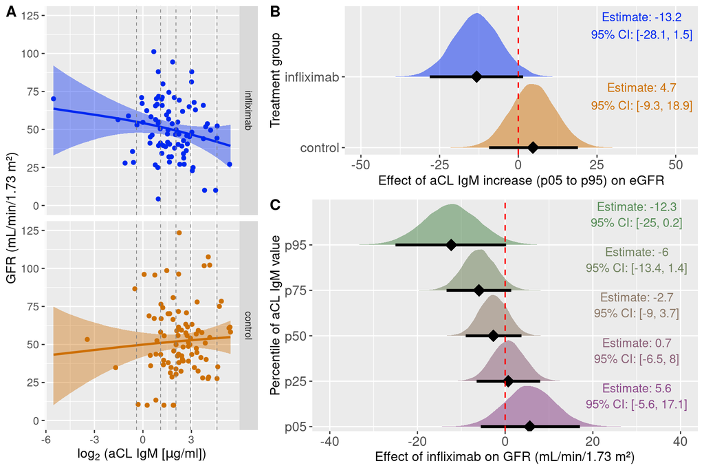

Figure 9: **Anti-cardiolipin IgM modulates the effect of infliximab on estimated glomerular filtration rate (eGFR).** (**A**) Predicted eGFR by anti-cardiolipin IgM for infliximab (upper) and control (lower) groups, with covariates held at their sample means. Shaded regions represent 95% credible intervals; dashed lines indicate the 5th, 25th, 50th, 75th, and 95th percentiles of cardiolipin levels. (**B**) Posterior distribution of the estimated change in eGFR when anti-cardiolipin IgM increases from the 5th to the 95th sample percentile. (**C**) Posterior distribution of the effect of infliximab on eGFR across anti-cardiolipin IgM percentiles. Results are from a multivariable Bayesian robust regression with B-splines.

```r
plotac <- 'sup_figure_5'
path <- "gitignore/figures"


fig <- cowplot::plot_grid(fig_b, fig_c,
  rel_heights = c(0.7, 1),
  labels = c("B", "C"),
  ncol = 1
)

assign(
  plotac,
  cowplot::plot_grid(
    fig_a, fig,
    rel_widths = c(0.6, 1),
    labels = c("A", "")
  )
)

get(plotac)

if (file.exists(paste0(path, "/", plotac)) == FALSE) {
  ggsave(
    path = paste0(path),
    filename = plotac,
    device = "pdf",
    width = 9,
    height = 6
  )
}
```

# 10 Summarizing table

## 10.1 Logistic models

**Open code**

```r
data_results_table_OR <- data.frame(

  outcome = c('DGF', 'DGF', 'infection', 'infection'),

  antibody = c('aCL IgG', 'aCL IgM', 'aPE-dep IgG', 'aPE-ind IgG'),

  `OR_p05` = c('0.13 [0.03, 0.49]',
               '0.23 [0.05, 0.94]',
               '3.73 [1.15, 12.69]',
               '3.12 [1.11, 9.08]'),

  OR_p25 = c('0.34 [0.13, 0.80]',
             '0.48 [0.19, 1.15]',
             '2.26 [1.005, 5.19]',
             '2.34 [1.01, 5.56]'),

  OR_p50 = c('0.59 [0.27, 1.25]',
             '0.77 [0.37, 1.61]',
             '1.68 [0.82, 3.47]',
             '1.75 [0.85, 3.68]'),

  OR_p75 = c('1.37 [0.60, 3.22]',
             '1.22 [0.52, 2.85]',
             '1.10 [0.49, 2.42]',
             '1.02 [0.45, 2.26]'),

  OR_p95 = c('6.24 [1.38, 30.32]',
             '2.79 [0.66, 12.59]',
             '0.36 [0.07, 1.75]',
             '0.23 [0.03, 1.33]'),

    p95_per_p05_ROR = c('46.6 [4.4, 610.0]',
                     '12.8 [1.1, 166.6]',
                     '0.097 [0.008, 0.995]',
                     '0.08 [0.005, 0.75]'
                     )
)



kableExtra::kable(data_results_table_OR)
```

Table 23: *Table 1*: Results from multivariable Bayesian logistic regression models with B-splines, estimating the non-linear interaction between natural antibody (`antibody`) levels and infliximab (`IFX`) treatment on the specified `outcome`. The `antibody` include anti-cardiolipin IgG or IgM (aCL IgG or IgM) and co-factor (ind)dependent anti-phosphatidylethanolamine (aPE-dep IgG and aPE-ind IgG respectively). IFX treatment effects (odds ratio [`OR`, infliximab vs. placebo]) are reported at the 5th, 25th, 50th, 75th, and 95th sample percentiles of nAb levels, each with [95% credible interval]. Interaction magnitudes are expressed as the ratio of odds ratios (`ROR`) for the IFX effect at the 95th vs. 5th percentile of the nAb level (`p95_per_p05_ROR`) with [95% credible intervals]

| outcome | antibody | OR_p05 | OR_p25 | OR_p50 | OR_p75 | OR_p95 | p95_per_p05_ROR |
| --- | --- | --- | --- | --- | --- | --- | --- |
| DGF | aCL IgG | 0.13 [0.03, 0.49] | 0.34 [0.13, 0.80] | 0.59 [0.27, 1.25] | 1.37 [0.60, 3.22] | 6.24 [1.38, 30.32] | 46.6 [4.4, 610.0] |
| DGF | aCL IgM | 0.23 [0.05, 0.94] | 0.48 [0.19, 1.15] | 0.77 [0.37, 1.61] | 1.22 [0.52, 2.85] | 2.79 [0.66, 12.59] | 12.8 [1.1, 166.6] |
| infection | aPE-dep IgG | 3.73 [1.15, 12.69] | 2.26 [1.005, 5.19] | 1.68 [0.82, 3.47] | 1.10 [0.49, 2.42] | 0.36 [0.07, 1.75] | 0.097 [0.008, 0.995] |
| infection | aPE-ind IgG | 3.12 [1.11, 9.08] | 2.34 [1.01, 5.56] | 1.75 [0.85, 3.68] | 1.02 [0.45, 2.26] | 0.23 [0.03, 1.33] | 0.08 [0.005, 0.75] |

## 10.2 Linear models (eGFR)

**Open code**

```r
data_results_table_cont <- data.frame(

  outcome = c('eGFR',  'eGFR', 'eGFR_last_prefail'),

  antibody = c('aCL IgG', 'aCL IgM', 'aCL IgG'),

  eff_p05 = c('7.3 [-3.3, 18.0]',
              '5.6 [-5.6, 17.1]',
              '6.4 [-3.9, 16.7]'),

  eff_p25 = c('2.0 [-5.1, 9.2]',
              '0.7 [-6.5, 8.0]',
              '1.4 [-5.5, 8.3]'),

  eff_p50 = c('-1.3 [-7.7, 5.0]',
              '-2.7 [-9.0, 3.7]',
              '-1.8 [-8.0, 4.4]'),

  eff_p75 = c('-6.5 [-13.6, 0.6]',
              '-6.0 [-13.4, 1.4]',
              '-6.6 [-13.5, 0.2]'),

  eff_p95 = c('-15.9 [-28.9, -3.3]',
              '-12.3 [-25.0, 0.2]',
              '-15.7 [-28.2, -3.5]'),

  p95_p05_DE = c('-23.2 [-42.1, -4.2]',
                 '-17.9 [-38.0, 1.9]',
                 '-22.0 [-40.5, 4.0]')
)

kableExtra::kable(data_results_table_cont)
```

Table 24: *Table 2*: Results from multivariable Bayesian robust regression models with B-splines, estimating the non-linear interaction between natural antibody (`antibody`) levels and infliximab (`IFX`) treatment on the specified `outcome` (either eGFR with imputed values in cases of graft failure within two years of follow-up [`eGFR`], or based on the last pre-failure eGFR measurement within two years [`eGFR_last_prefail`]). The `antibody` include anti-cardiolipin (aCL) IgG or IgM. IFX treatment absolute effect (`eff`, infliximab minus placebo) are reported at the 5th, 25th, 50th, 75th, and 95th sample percentiles of nAb levels, each with [95% credible interval]. Interaction magnitudes are expressed as the difference in treatment effects at the 95th minus 5th percentile (`p95_p05_DE`) with [95% credible intervals]

| outcome | antibody | eff_p05 | eff_p25 | eff_p50 | eff_p75 | eff_p95 | p95_p05_DE |
| --- | --- | --- | --- | --- | --- | --- | --- |
| eGFR | aCL IgG | 7.3 [-3.3, 18.0] | 2.0 [-5.1, 9.2] | -1.3 [-7.7, 5.0] | -6.5 [-13.6, 0.6] | -15.9 [-28.9, -3.3] | -23.2 [-42.1, -4.2] |
| eGFR | aCL IgM | 5.6 [-5.6, 17.1] | 0.7 [-6.5, 8.0] | -2.7 [-9.0, 3.7] | -6.0 [-13.4, 1.4] | -12.3 [-25.0, 0.2] | -17.9 [-38.0, 1.9] |
| eGFR_last_prefail | aCL IgG | 6.4 [-3.9, 16.7] | 1.4 [-5.5, 8.3] | -1.8 [-8.0, 4.4] | -6.6 [-13.5, 0.2] | -15.7 [-28.2, -3.5] | -22.0 [-40.5, 4.0] |

# 11 GFR: Mediation and AB-subgroup analysis

## 11.1 Define the subgroups

**Open code**

```r
GPL_median <- median(data_model_priorImpute$GPL_BC_log2)
GPL_median
## [1] -0.1046076

data_imputed_highGPL <- data.frame(subset(
  data_first,
  subset = data_first$GPL_BC_log2 >= GPL_median
))


data_imputed_lowGPL <- subset(
  data_first,
  subset = data_first$GPL_BC_log2 < GPL_median
)
```

### 11.1.1 Priors

**Open code**

```r
create_prior <- function(var, sigma, class = "b") {
  set_prior(paste0("normal(0, ", sigma, ")"), class = class, coef = var)
}

GFR_sd <- sd(data_model_priorImpute$GFR_MDRD_3)
GFR_sd
## [1] 21.17099

priors_subset <- c(

  create_prior("Irec_ageM50",
    (2*GFR_sd) / sd(data_model_priorImpute$rec_age, na.rm = TRUE)
  ),
  create_prior("IHLA_MMM5",
    (2*GFR_sd) / sd(data_model_priorImpute$HLA_MM, na.rm = TRUE)
  ),
  create_prior("IKDPIM50",
    (2*GFR_sd) / sd(data_model_priorImpute$KDPI, na.rm = TRUE)
  ),
  create_prior("ICITM15",
    (2*GFR_sd) / sd(data_model_priorImpute$CIT, na.rm = TRUE)
  ),
  create_prior("male_sex",
    4*GFR_sd
  ),
  create_prior("perfusion_event",
    4*GFR_sd
  ),
  create_prior("male_sex_donor",
    4*GFR_sd
  ),
  create_prior("infliximab",
    4*GFR_sd
  ),

  set_prior(paste0("normal(", mean(data_model_priorImpute$GFR_MDRD_3), ", 200)"),
    class = "Intercept"
  )
)


create_prior <- function(var, sigma, class = "b",  resp = 'GFR_MDRD_3') {
  set_prior(paste0("normal(0, ", sigma, ")"), class = class, coef = var, resp = resp)
}

priors_mediation <- c(

  create_prior("Irec_ageM50",
    (2*GFR_sd) / sd(data_model_priorImpute$rec_age, na.rm = TRUE)
  ),

  create_prior("Irec_ageM50",
    (2*GFR_sd) / sd(data_model_priorImpute$rec_age, na.rm = TRUE),
    resp = 'DGF'
  ),

  create_prior("IHLA_MMM5",
    (2*GFR_sd) / sd(data_model_priorImpute$HLA_MM, na.rm = TRUE)
  ),
  create_prior("IHLA_MMM5",
    (2*GFR_sd) / sd(data_model_priorImpute$HLA_MM, na.rm = TRUE),
    resp = 'DGF'
  ),


  create_prior("IKDPIM50",
    (2*GFR_sd) / sd(data_model_priorImpute$KDPI, na.rm = TRUE)
  ),
  create_prior("IKDPIM50",
    (2*GFR_sd) / sd(data_model_priorImpute$KDPI, na.rm = TRUE),
    resp = 'DGF'
  ),

  create_prior("ICITM15",
    (2*GFR_sd) / sd(data_model_priorImpute$CIT, na.rm = TRUE)
  ),
  create_prior("ICITM15",
    (2*GFR_sd) / sd(data_model_priorImpute$CIT, na.rm = TRUE),
    resp = 'DGF'
  ),


  create_prior("male_sex",
    4*GFR_sd
  ),
  create_prior("male_sex",
    4*GFR_sd,
    resp = 'DGF'
  ),


  create_prior("perfusion_event",
    4*GFR_sd
  ),
  create_prior("perfusion_event",
    4*GFR_sd,
    resp = 'DGF'
  ),

  create_prior("male_sex_donor",
    4*GFR_sd
  ),
  create_prior("male_sex_donor",
    4*GFR_sd,
    resp = 'DGF'
  ),

  create_prior("infliximab",
    4*GFR_sd
  ),
  create_prior("infliximab",
    4*GFR_sd,
    resp = 'DGF'
  ),


  create_prior("DGF",
    4*GFR_sd
  )
)
```

### 11.1.2 GPL subgroup models

**Open code**

```r
model_GFR_MDRD_3_GPLsubset_low <- run(
  expr = brm(
    GFR_MDRD_3 ~
      male_sex +
      I(rec_age - 50) +
      male_sex_donor +
      I(KDPI - 50) +
      I(CIT - 15) +
      I(HLA_MM - 5) +
      perfusion_event +
      infliximab,
    family = student(),
    data = data_imputed_lowGPL,
    prior = priors_subset,
    backend = "cmdstanr",
    seed = 2025,
    cores = 4, chains = 4,
    iter = 6000, warmup = 2000,
    control = list(adapt_delta = 0.95)
  ),
  path = "gitignore/run/model_GFR_MDRD_3_GPLsubset_low",
  reuse = TRUE
)

summary(model_GFR_MDRD_3_GPLsubset_low)
##  Family: student
##   Links: mu = identity; sigma = identity; nu = identity
## Formula: GFR_MDRD_3 ~ male_sex + I(rec_age - 50) + male_sex_donor + I(KDPI - 50) + I(CIT - 15) + I(HLA_MM - 5) + perfusion_event + infliximab
##    Data: data_imputed_lowGPL (Number of observations: 88)
##   Draws: 4 chains, each with iter = 6000; warmup = 2000; thin = 1;
##          total post-warmup draws = 16000
##
## Regression Coefficients:
##                 Estimate Est.Error l-95% CI u-95% CI Rhat Bulk_ESS Tail_ESS
## Intercept          52.46      6.73    39.41    65.62 1.00    13509    12065
## male_sex           -0.09      5.11   -10.30     9.85 1.00    16331    11501
## Irec_ageM50         0.15      0.25    -0.33     0.64 1.00    14395    11553
## male_sex_donor     -1.99      4.89   -11.49     7.64 1.00    17367    12459
## IKDPIM50           -0.19      0.13    -0.45     0.07 1.00    13350    12286
## ICITM15             0.34      0.37    -0.39     1.07 1.00    15730    12347
## IHLA_MMM5          -2.18      1.74    -5.60     1.23 1.00    14721    12734
## perfusion_event    -9.86      5.01   -19.68    -0.08 1.00    16324    12384
## infliximab          6.69      4.93    -3.13    16.39 1.00    16223    11807
##
## Further Distributional Parameters:
##       Estimate Est.Error l-95% CI u-95% CI Rhat Bulk_ESS Tail_ESS
## sigma    20.58      1.94    16.91    24.59 1.00    11642     9925
## nu       21.25     13.21     5.25    54.99 1.00    12313    10772
##
## Draws were sampled using sample(hmc). For each parameter, Bulk_ESS
## and Tail_ESS are effective sample size measures, and Rhat is the potential
## scale reduction factor on split chains (at convergence, Rhat = 1).

model_GFR_MDRD_3_GPLsubset_high <- run(
  expr = brm(
    GFR_MDRD_3 ~
      male_sex +
      I(rec_age - 50) +
      male_sex_donor +
      I(KDPI - 50) +
      I(CIT - 15) +
      I(HLA_MM - 5) +
      perfusion_event +
      #GPL_BC_log2 +
      infliximab,
    family = student(),
    data = data_imputed_highGPL,
    prior = priors_subset,
    backend = "cmdstanr",
    seed = 2025,
    cores = 4, chains = 4,
    iter = 6000, warmup = 2000,
    control = list(adapt_delta = 0.95)
  ),
  path = "gitignore/run/model_GFR_MDRD_3_GPLsubset_high",
  reuse = TRUE
)

summary(model_GFR_MDRD_3_GPLsubset_high)
##  Family: student
##   Links: mu = identity; sigma = identity; nu = identity
## Formula: GFR_MDRD_3 ~ male_sex + I(rec_age - 50) + male_sex_donor + I(KDPI - 50) + I(CIT - 15) + I(HLA_MM - 5) + perfusion_event + infliximab
##    Data: data_imputed_highGPL (Number of observations: 89)
##   Draws: 4 chains, each with iter = 6000; warmup = 2000; thin = 1;
##          total post-warmup draws = 16000
##
## Regression Coefficients:
##                 Estimate Est.Error l-95% CI u-95% CI Rhat Bulk_ESS Tail_ESS
## Intercept          55.29      4.70    46.08    64.60 1.00    15838    12336
## male_sex            2.39      4.19    -5.89    10.63 1.00    16915    12278
## Irec_ageM50        -0.12      0.19    -0.51     0.25 1.00    15773    11909
## male_sex_donor      2.09      4.33    -6.56    10.54 1.00    14250    11634
## IKDPIM50           -0.29      0.10    -0.49    -0.09 1.00    13747    12356
## ICITM15             0.22      0.27    -0.32     0.74 1.00    15390    12124
## IHLA_MMM5          -0.33      1.40    -3.09     2.39 1.00    16515    12259
## perfusion_event    -3.22      4.50   -11.96     5.71 1.00    14330    12062
## infliximab        -10.99      4.11   -19.06    -2.97 1.00    15817    11701
##
## Further Distributional Parameters:
##       Estimate Est.Error l-95% CI u-95% CI Rhat Bulk_ESS Tail_ESS
## sigma    16.97      1.85    13.32    20.70 1.00     9173     7985
## nu       17.87     12.93     3.75    52.17 1.00    10702     9238
##
## Draws were sampled using sample(hmc). For each parameter, Bulk_ESS
## and Tail_ESS are effective sample size measures, and Rhat is the potential
## scale reduction factor on split chains (at convergence, Rhat = 1).
```

### 11.1.3 Mediation

Prepare table

**Open code**

```r
# Model for the mediator DGF
m1 <- bf(
  DGF ~ scale(male_sex) +
    scale(rec_age) +
    scale(male_sex_donor) +
    scale(KDPI) +
    scale(CIT) +
    scale(HLA_MM) +
    scale(perfusion_event) +
    infliximab,
  family = bernoulli(link = "logit")
)


# Model for the outcome GFR
m2 <- bf(
  GFR_MDRD_3 ~ scale(male_sex) +
    scale(rec_age) +
    scale(male_sex_donor) +
    scale(KDPI) +
    scale(CIT) +
    scale(HLA_MM) +
    scale(perfusion_event) +
    infliximab +
    DGF,
  family = student()
)

## Joint model - Low GPL_BC
model_GFR_GPL_mediate_low <- run(
  expr = brm(
  m1 + m2 + set_rescor(FALSE),
  data = data_imputed_lowGPL,
  priors_mediation,
  backend = "cmdstanr",
  seed = 2025,
  cores = 4, chains = 4,
  iter = 6000, warmup = 2000,
  control = list(adapt_delta = 0.95), refresh = 0),
  path = "gitignore/run/model_GFR_2_GPL_mediate_low",
  reuse = TRUE
)


## Joint model - high GPL_BC
model_GFR_GPL_mediate_high <- run(
  expr = brm(
  m1 + m2 + set_rescor(FALSE),
  data = data_imputed_highGPL,
  priors_mediation,
  backend = "cmdstanr",
  seed = 2025,
  cores = 4, chains = 4,
  iter = 6000, warmup = 2000,
  control = list(adapt_delta = 0.95), refresh = 0),
  path = "gitignore/run/model_GFR_2_GPL_mediate_high",
  reuse = TRUE
)



post_fix_low <- as.data.frame(model_GFR_GPL_mediate_low) %>%

  select(b_GFRMDRD3_Intercept, b_GFRMDRD3_infliximab, b_GFRMDRD3_DGF,
         b_DGF_Intercept, b_DGF_infliximab) %>%

  mutate(predicted_DGF_ctrl = inv_logit(b_DGF_Intercept),
         predicted_DGF_infx = inv_logit(b_DGF_Intercept + b_DGF_infliximab)) %>%

  mutate(
    indirect_pred_ctrl = b_GFRMDRD3_Intercept +
      (b_GFRMDRD3_infliximab * mean(data_imputed_lowGPL$infliximab) ) +
      (b_GFRMDRD3_DGF * predicted_DGF_ctrl),

    indirect_pred_infx = b_GFRMDRD3_Intercept +
      (b_GFRMDRD3_infliximab * mean(data_imputed_lowGPL$infliximab) ) +
      (b_GFRMDRD3_DGF * predicted_DGF_infx),
      ) %>%

  mutate(
    `Direct Effect (ADE)`  = b_GFRMDRD3_infliximab,
    `Indirect Effect (ACME)` = indirect_pred_infx - indirect_pred_ctrl,
    `Mediator Effect` = b_GFRMDRD3_DGF,
    `Total Effect` = (
           (indirect_pred_infx - indirect_pred_ctrl) + b_GFRMDRD3_infliximab
           )
         ) %>%
  select(`Direct Effect (ADE)`:`Total Effect`)

med_eff_low <- sapply(
  post_fix_low,
  function(p) quantile(p, probs = c(0.5, 0.025, 0.975))
  ) %>% t()


post_fix_high <- as.data.frame(model_GFR_GPL_mediate_high) %>%

  select(b_GFRMDRD3_Intercept, b_GFRMDRD3_infliximab, b_GFRMDRD3_DGF,
         b_DGF_Intercept, b_DGF_infliximab) %>%

  mutate(predicted_DGF_ctrl = inv_logit(b_DGF_Intercept),
         predicted_DGF_infx = inv_logit(b_DGF_Intercept + b_DGF_infliximab)) %>%

  mutate(
    indirect_pred_ctrl = b_GFRMDRD3_Intercept +
      (b_GFRMDRD3_infliximab * mean(data_imputed_highGPL$infliximab) ) +
      (b_GFRMDRD3_DGF * predicted_DGF_ctrl),

    indirect_pred_infx = b_GFRMDRD3_Intercept +
      (b_GFRMDRD3_infliximab * mean(data_imputed_highGPL$infliximab) ) +
      (b_GFRMDRD3_DGF * predicted_DGF_infx),
      ) %>%

  mutate(
    `Direct Effect (ADE)`  = b_GFRMDRD3_infliximab,
    `Indirect Effect (ACME)` = indirect_pred_infx - indirect_pred_ctrl,
    `Mediator Effect` = b_GFRMDRD3_DGF,
    `Total Effect` = (
           (indirect_pred_infx - indirect_pred_ctrl) + b_GFRMDRD3_infliximab
           )
         ) %>%
  select(`Direct Effect (ADE)`:`Total Effect`)


med_eff_high <- sapply(
  post_fix_high,
  function(p) quantile(p, probs = c(0.5, 0.025, 0.975))
  ) %>% t()


mediation_effect <- data.frame(
  effect = rownames(med_eff_low),
  `Low_aCL` = paste0(
    round(c(med_eff_low[, 1]), 1),
    ' [',
    round(c(med_eff_low[, 2]), 1),
    ', ',
    round(c(med_eff_low[, 3]), 1),
    ']'
    ),
  `High_aCL` = paste0(
    round(c(med_eff_high[, 1]), 1),
    ' [',
    round(c(med_eff_high[, 2]), 1),
    ', ',
    round(c(med_eff_high[, 3]), 1),
    ']'
    )
  )
```

Print table

**Open code**

```r
kableExtra::kable(mediation_effect)
```

Table 25: *Supplementary Table 7*: Results from Bayesian mediation analyses assessing the direct and indirect effects of infliximab on estimated glomerular filtration rate (eGFR). The indirect effect operates through the impact of infliximab on delayed graft function (DGF) risk. Separate joint models were used for patients with anti-cardiolipin IgG (aCL IgG) below (**Low aCL**) and at/above the median (**High aCL**). The Average Direct Effect (`ADE` [95% credible interval]) estimates the direct effect of infliximab on eGFR, controlling for the indirect pathway via DGF and other covariates. The Average Causal Mediation Effect (`ACME` [95% credible interval]) quantifies the indirect effect via DGF. The `Mediator Effect` represents the effect of DGF on eGFR, adjusting for infliximab and other covariates. The `Total Effect` captures the overall impact of infliximab on eGFR, combining both direct and indirect pathways.

| effect | Low_aCL | High_aCL |
| --- | --- | --- |
| Direct Effect (ADE) | 1 [-8.4, 10.2] | -8.9 [-16.8, -1.1] |
| Indirect Effect (ACME) | 5.1 [1.3, 10.7] | -2.1 [-6.2, 0.2] |
| Mediator Effect | -17.8 [-27.6, -7.9] | -11.4 [-19.9, -2.7] |
| Total Effect | 6.4 [-3.3, 15.8] | -11.2 [-19.5, -3.2] |

# 12 Models without large GPL_BC

**Open code**

```r
infl_max <- max(data_first[which(data_first$infliximab == 1), 'GPL_BC_log2']); infl_max
## [1] 2.740331
ctrl_max <- max(data_first[which(data_first$infliximab == 0), 'GPL_BC_log2']); ctrl_max
## [1] 4.949819

data_sens <- data_first %>% filter(GPL_BC_log2 <= infl_max) %>%
  mutate(group = factor(if_else(infliximab == 1, 'infliximab', 'control')))
```

## 12.1 DGF by GPL_BC

### 12.1.1 Priors

**Open code**

```r
# function to get prior
create_prior <- function(var, sigma, class = "b", coef = NULL) {
  set_prior(paste0("normal(0, ", sigma, ")"), class = class, coef = coef)
}


priors_interaction_pnl <- c(
  create_prior("Irec_ageM50",
               2 / sd(data_sens$rec_age, na.rm = TRUE),
               coef = "Irec_ageM50"),
  create_prior("IHLA_MMM5",
               2 / sd(data_sens$HLA_MM, na.rm = TRUE),
               coef = "IHLA_MMM5"),
  create_prior("IKDPIM50",
               2 / sd(data_sens$KDPI, na.rm = TRUE),
               coef = "IKDPIM50"),
  create_prior("ICITM15",
               2 / sd(data_sens$CIT, na.rm = TRUE),
               coef = "ICITM15"),
  create_prior("male_sex",
               4,
               coef = "male_sex"),
  create_prior("perfusion_event",
               4,
               coef = "perfusion_event"),
  create_prior("male_sex_donor",
               4,
               coef = "male_sex_donor"),

  create_prior("infliximab",
               4,
               coef = "infliximab"),

 set_prior("student_t(3, 0, 0.6)", class = "sds",
           coef = 's(GPL_BC_log2, bs = "ps", k = 5)'),

 set_prior("student_t(3, 0, 0.3)", class = "sds",
           coef = 's(GPL_BC_log2, by = infliximab, bs = "ps", k = 5)'),

  set_prior(paste0("normal(", logit(mean(data_sens$DGF)), ", 10)"),
            class = "Intercept")
)
```

### 12.1.2 Model

**Open code**

```r
model_dgf_GPL_BC_interaction_NL_sens <- run(
  expr = brm(
    DGF ~
    male_sex +
    I(rec_age - 50) +
    male_sex_donor +
    I(KDPI - 50) +
    I(CIT - 15) +
    I(HLA_MM - 5) +
    perfusion_event +
    infliximab +
    s(GPL_BC_log2, bs = 'ps', k = 5) +
    s(GPL_BC_log2, by = infliximab, bs = 'ps', k = 5),
    family = bernoulli(),
    data = data_sens,
    prior = priors_interaction_pnl,
    backend = "cmdstanr",
    seed = 2025,
    cores = 4, chains = 4,
    iter = 5000, warmup = 2000,
    control = list(adapt_delta = 0.95)
  ),
  path = "gitignore/run/model_dgf_GPL_BC_interaction_NL_sens",
  reuse = TRUE
)

summary(model_dgf_GPL_BC_interaction_NL_sens, robust = TRUE)
##  Family: bernoulli
##   Links: mu = logit
## Formula: DGF ~ male_sex + I(rec_age - 50) + male_sex_donor + I(KDPI - 50) + I(CIT - 15) + I(HLA_MM - 5) + perfusion_event + infliximab + s(GPL_BC_log2, bs = "ps", k = 5) + s(GPL_BC_log2, by = infliximab, bs = "ps", k = 5)
##    Data: data_sens (Number of observations: 170)
##   Draws: 4 chains, each with iter = 5000; warmup = 2000; thin = 1;
##          total post-warmup draws = 12000
##
## Smoothing Spline Hyperparameters:
##                               Estimate Est.Error l-95% CI u-95% CI Rhat
## sds(sGPL_BC_log2_1)               0.45      0.40     0.02     1.88 1.00
## sds(sGPL_BC_log2infliximab_1)     0.22      0.21     0.01     1.07 1.00
##                               Bulk_ESS Tail_ESS
## sds(sGPL_BC_log2_1)               7041     5216
## sds(sGPL_BC_log2infliximab_1)     8954     5147
##
## Regression Coefficients:
##                           Estimate Est.Error l-95% CI u-95% CI Rhat Bulk_ESS
## Intercept                    -1.23      0.49    -2.25    -0.26 1.00    11736
## male_sex                      1.15      0.41     0.35     1.99 1.00    12193
## Irec_ageM50                  -0.01      0.02    -0.05     0.03 1.00    11702
## male_sex_donor                0.31      0.40    -0.45     1.11 1.00    10843
## IKDPIM50                      0.00      0.01    -0.02     0.02 1.00    10691
## ICITM15                       0.09      0.03     0.03     0.15 1.00    10923
## IHLA_MMM5                     0.25      0.14    -0.01     0.52 1.00    10410
## perfusion_event              -0.39      0.39    -1.17     0.39 1.00    11052
## infliximab                    0.06      3.89    -7.58     7.58 1.00     3997
## sGPL_BC_log2_1                2.05      1.19    -0.39     4.66 1.00     7724
## sGPL_BC_log2:infliximab_1     1.65      2.73    -3.57     6.90 1.00     4254
## sGPL_BC_log2:infliximab_2    -2.09      1.33    -4.69     0.48 1.00     4694
##                           Tail_ESS
## Intercept                     9635
## male_sex                      9580
## Irec_ageM50                   9522
## male_sex_donor                8929
## IKDPIM50                      8477
## ICITM15                       8949
## IHLA_MMM5                     8917
## perfusion_event               9013
## infliximab                    5974
## sGPL_BC_log2_1                6425
## sGPL_BC_log2:infliximab_1     6490
## sGPL_BC_log2:infliximab_2     6814
##
## Draws were sampled using sample(hmc). For each parameter, Bulk_ESS
## and Tail_ESS are effective sample size measures, and Rhat is the potential
## scale reduction factor on split chains (at convergence, Rhat = 1).
prior_summary(model_dgf_GPL_BC_interaction_NL_sens)
##                           prior     class
##                          (flat)         b
##    normal(0, 0.281193624307594)         b
##     normal(0, 1.32489040521642)         b
##   normal(0, 0.0974514024084987)         b
##                    normal(0, 4)         b
##    normal(0, 0.194443540354437)         b
##                    normal(0, 4)         b
##                    normal(0, 4)         b
##                    normal(0, 4)         b
##                          (flat)         b
##                          (flat)         b
##                          (flat)         b
##  normal(-0.658055860748675, 10) Intercept
##            student_t(3, 0, 2.5)       sds
##            student_t(3, 0, 0.6)       sds
##            student_t(3, 0, 0.3)       sds
##                                               coef group resp dpar nlpar lb ub
##
##                                            ICITM15
##                                          IHLA_MMM5
##                                           IKDPIM50
##                                         infliximab
##                                        Irec_ageM50
##                                           male_sex
##                                     male_sex_donor
##                                    perfusion_event
##                                     sGPL_BC_log2_1
##                          sGPL_BC_log2:infliximab_1
##                          sGPL_BC_log2:infliximab_2
##
##                                                                           0
##                   s(GPL_BC_log2, bs = "ps", k = 5)                        0
##  s(GPL_BC_log2, by = infliximab, bs = "ps", k = 5)                        0
##        source
##       default
##          user
##          user
##          user
##          user
##          user
##          user
##          user
##          user
##  (vectorized)
##  (vectorized)
##  (vectorized)
##          user
##       default
##          user
##          user

tr2 <- round(exp(fixef(model_dgf_GPL_BC_interaction_NL_sens,
                       robust = TRUE)[-c(1,9:12), c(1,3,4)]), 2)

antibody_seq <- quantile(data_sens$GPL_BC_log2,
                         probs = c(0.05, 0.95))

asl <- length(antibody_seq)
quant_dif <- antibody_seq[2] - antibody_seq[1]

data_prediction <- data.frame(
    male_sex = rep(mmale_sex, 2*length(antibody_seq)),
  `male_sex_donor` = rep(mmale_sex_donor, 2*length(antibody_seq)),
  `perfusion_event` = rep(mperfusion_event, 2*length(antibody_seq)),
  `infliximab` = c(rep(0, length(antibody_seq)), rep(1, length(antibody_seq))),
  `rec_age` = rep(mrec_age, 2*length(antibody_seq)),
  `KDPI` = rep(mKDPI, 2*length(antibody_seq)),
  `CIT` = rep(mCIT, 2*length(antibody_seq)),
  `HLA_MM` = rep(mHLA_MM, 2*length(antibody_seq)),
  `GPL_BC_log2` = c(antibody_seq, antibody_seq)
  )

tr <-  posterior_epred(
    model_dgf_GPL_BC_interaction_NL_sens,
    newdata = data_prediction)

prediction_ctrl <- tr[, c(1:asl)]
prediction_infliximab <- tr[, c((asl+1):(asl*2))]

## get odds ratio for infliximab effect across antibody values
prediction <- (
  (prediction_infliximab/(1-prediction_infliximab))/
     (prediction_ctrl/(1-prediction_ctrl))
  ) %>% data.frame()
names(prediction) <- c('p05', 'p95')

infliximab_GPL_BC_log2_int <- quantile(
  exp((log(prediction$p95) - log(prediction$p05))/scaling_unit),
         probs = c(0.5, 1/40, 39/40))

tr2 <- rbind(tr2, round(infliximab_GPL_BC_log2_int, 2))
row.names(tr2)[8] <- 'infliximab:GPL_BC_log2'
colnames(tr2)[1] <- '(R)OR'
kableExtra::kable(tr2)
```

Table 26: Results from multivariable Bayesian logistic regression models incorporating a non-linear interaction between anti-cardiolipin IgG (`GPL_BC_log2`) and `infliximab` treatment on delayed graft function (`DGF`), while accounting for other covariates, **restricting the dataset to patients with anti-cardiolipin IgG levels within the range observed in the infliximab group**. Effects are presented as odds ratios (`OR`), with the last row reporting the ratio of odds ratios (`ROR`). The ROR represents the estimated ratio of infliximab’s treatment effect at the 95th versus the 5th percentile of anti-cardiolipin IgG, quantifying the interaction effect.`Q2.5` and `Q97.5`: lower and upper bounds of the 95% credible interval, respectively.

|  | (R)OR | Q2.5 | Q97.5 |
| --- | --- | --- | --- |
| male_sex | 3.16 | 1.43 | 7.31 |
| Irec_ageM50 | 0.99 | 0.95 | 1.03 |
| male_sex_donor | 1.36 | 0.64 | 3.04 |
| IKDPIM50 | 1.00 | 0.98 | 1.02 |
| ICITM15 | 1.09 | 1.03 | 1.16 |
| IHLA_MMM5 | 1.28 | 0.99 | 1.68 |
| perfusion_event | 0.68 | 0.31 | 1.47 |
| infliximab:GPL_BC_log2 | 49.76 | 4.11 | 715.86 |

### 12.1.3 Visualisation - penalized non-linear effect

Extract posterior draws

**Open code**

```r
antibody_perc <- quantile(data_sens$GPL_BC_log2,
                           probs = c(0, 0.02, 0.05, 0.25, 0.5, 0.75, 0.95, 0.98, 1))

antibody_seq <- seq(antibody_perc[1],
                      antibody_perc[length(antibody_perc)],
                      length.out = 101)

## create prediction
data_prediction <- data.frame(
    male_sex = rep(mmale_sex, 2*length(antibody_seq)),
  `male_sex_donor` = rep(mmale_sex_donor, 2*length(antibody_seq)),
  `perfusion_event` = rep(mperfusion_event, 2*length(antibody_seq)),
  `infliximab` = c(rep(0, length(antibody_seq)), rep(1, length(antibody_seq))),
  `rec_age` = rep(mrec_age, 2*length(antibody_seq)),
  `KDPI` = rep(mKDPI, 2*length(antibody_seq)),
  `CIT` = rep(mCIT, 2*length(antibody_seq)),
  `HLA_MM` = rep(mHLA_MM, 2*length(antibody_seq)),
  `GPL_BC_log2` = c(antibody_seq, antibody_seq)
  )

prediction <- data.frame(
  posterior_epred(
    model_dgf_GPL_BC_interaction_NL_sens,
    newdata = data_prediction) %>% posterior_summary(
      robust = TRUE
      ) %>% data.frame() %>% select(-Est.Error),
  group = factor(if_else(data_prediction$infliximab == 1, 'infliximab', 'control')),
  GPL_BC_log2 = data_prediction$GPL_BC_log2)
```

Figure A

**Open code**

```r
cole <- c('#CD7006', '#0028F0')

fig_a <- prediction %>%
  mutate(group = factor(group, levels = c("infliximab", "control"))) %>%
  ggplot(aes(x = GPL_BC_log2, y = Estimate, col = group, fill = group)) +
  geom_line(aes(y = Estimate), linewidth = 1) +
  scale_y_continuous(limits = c(0, 1),
                     breaks = c(seq(0, 1, by = 0.2))) +

  geom_ribbon(aes(ymin = `Q2.5`, ymax = `Q97.5`),
               alpha = 0.4,  color = NA) +

  labs(x = expression(log[2]~"(aCL IgG ["*mu*"g/ml])"), y = "DGF risk") +
  scale_color_manual(values = cole,
                       name = "group",
                       breaks = c('control', 'infliximab'),
                       labels = c('control', 'infliximab')) +

  scale_fill_manual(values = cole,
                       name = "group",
                       breaks = c('control', 'infliximab'),
                       labels = c('control', 'infliximab')) +

  facet_grid(rows = vars(group)) +

  theme(axis.text=element_text(size=10),
        axis.title=element_text(size=12),
        strip.text.x = element_text(size = 12),
        legend.position = "none") +

  geom_rug(
    data = data_sens %>% filter(DGF == 0),
    aes(x = GPL_BC_log2),
    sides = "b",
    color = "black",
    size = 0.12,
    inherit.aes = FALSE
  ) +
  geom_rug(
    data = data_sens %>% filter(DGF == 1),
    aes(x = GPL_BC_log2),
     sides = "t",
    color = "black",
    linewidth = 0.12,
    inherit.aes = FALSE
  ) +
  geom_vline(xintercept = antibody_perc[3:7], linetype = 2,
                            color = "grey50", size = 0.3)
```

Figure B

**Open code**

```r
antibody_seq <- antibody_perc[c(3, 7)]
antibody_seq
##        5%       95%
## -1.801712  2.071126

data_prediction <- data.frame(
   male_sex = rep(mmale_sex, 2*length(antibody_seq)),
  `male_sex_donor` = rep(mmale_sex_donor, 2*length(antibody_seq)),
  `perfusion_event` = rep(mperfusion_event, 2*length(antibody_seq)),
  `infliximab` = c(rep(0, length(antibody_seq)), rep(1, length(antibody_seq))),
  `rec_age` = rep(mrec_age, 2*length(antibody_seq)),
  `KDPI` = rep(mKDPI, 2*length(antibody_seq)),
  `CIT` = rep(mCIT, 2*length(antibody_seq)),
  `HLA_MM` = rep(mHLA_MM, 2*length(antibody_seq)),
  `GPL_BC_log2` = c(antibody_seq, antibody_seq)
  )

tr <-  posterior_epred(
    model_dgf_GPL_BC_interaction_NL_sens,
    newdata = data_prediction)

tr_ctrl <- (logit(tr[,c(ncol(tr)/2)]) - logit(tr[,c(1)]))
tr_infliximab <- (logit(tr[,c(ncol(tr))]) - logit(tr[,c(ncol(tr)/2)+1]))

post_fix <- data.frame(
  b_GPL_BC_log2 = tr_ctrl,
  b_GPL_BC_log2_infliximab = tr_infliximab
)

tr <- post_fix %>%
  mutate(control = exp(b_GPL_BC_log2),
         infliximab = exp(b_GPL_BC_log2_infliximab)) %>%
  select(control, infliximab) %>%
  data.frame()

CIS <- sapply(
  tr,
  function(p) quantile(p, probs = c(1/40, 39/40, 0.5, 1e-3, 1-1e-3))
  ) %>%
  round(2)

CIS
##       control infliximab
## 2.5%     0.03       1.76
## 97.5%    1.05      53.51
## 50%      0.18       9.02
## 0.1%     0.01       0.64
## 99.9%    3.12     171.65

xpos <- 323

fig_b <- tr %>%
  pivot_longer(values_to = 'value',
               cols = c('control', 'infliximab'),
               names_to = 'group') %>%
  ggplot(aes(x = value, y = group, fill = group)) +

  stat_halfeye(.width = c(0.95), slab_alpha=0.5,
               linewidth = 5,
               shape = 18,
               point_size = 5,
               normalize = "groups",
               p_limits = c(1e-3, 1-1e-3)) +

    labs(x = 'Effect (OR) of aCL IgG increase (p05 to p95) on DGF',
         y = 'Treatment group') +

  scale_fill_manual(values = cole,
                       name = "Treatment group",
                       breaks = c('control', 'infliximab'),
                       labels = c('control', 'infliximab')) +

  scale_y_discrete(expand = expansion(add = 0.1)) +
  coord_cartesian(xlim = c(1/600, 1800)) +
  scale_x_continuous(transform = 'log2',
                     breaks = c(1/512, 1/64, 1/8, 1, 8, 64, 512),
                     labels = c("1/512", "1/64", "1/8", "1", "8", "64", "512")) +

  geom_vline(xintercept = 1, linetype = 2,
                color = "red", size = 0.6) +

  theme(axis.text = element_text(size = 12),
        axis.title = element_text(size = 12)) +

  theme(legend.position = "none") +

  annotate("text",  x = xpos, y = 2.85 ,
           label = paste0("Odds ratio: ", CIS[3,2]),
           color = cole[2] ) +

  annotate("text",  x = xpos, y = 1.85 ,
           label = paste0("Odds ratio: ", CIS[3,1]),
           color = cole[1] ) +

  annotate("text",  x = xpos, y = 2.6 ,
           label = paste0("95% CI: [", CIS[1,2], ", ", CIS[2,2], "]"),
           color = cole[2] ) +

  annotate("text",  x = xpos, y = 1.6 ,
           label = paste0("95% CI: [", CIS[1,1], ", ", CIS[2,1], "]"),
           color = cole[1] )
```

Figure C

**Open code**

```r
cole <- c("#8B4789", "#8B5F77", "#8B7765", "#6F815C", "#548B54")
xpos <- 240
xseq <- c(1/64, 1/8, 1, 8, 64, 512)

antibody_seq <- antibody_perc[c(3, 4, 5, 6, 7)]
antibody_seq
##         5%        25%        50%        75%        95%
## -1.8017117 -0.7949708 -0.1340217  0.6308746  2.0711263

asl <- length(antibody_seq)

data_prediction <- data.frame(
    male_sex = rep(mmale_sex, 2*length(antibody_seq)),
  `male_sex_donor` = rep(mmale_sex_donor, 2*length(antibody_seq)),
  `perfusion_event` = rep(mperfusion_event, 2*length(antibody_seq)),
  `infliximab` = c(rep(0, length(antibody_seq)), rep(1, length(antibody_seq))),
  `rec_age` = rep(mrec_age, 2*length(antibody_seq)),
  `KDPI` = rep(mKDPI, 2*length(antibody_seq)),
  `CIT` = rep(mCIT, 2*length(antibody_seq)),
  `HLA_MM` = rep(mHLA_MM, 2*length(antibody_seq)),
  `GPL_BC_log2` = c(antibody_seq, antibody_seq)
  )

tr <-  posterior_epred(
    model_dgf_GPL_BC_interaction_NL_sens,
    newdata = data_prediction)

prediction_ctrl <- tr[, c(1:asl)]

prediction_infliximab <- tr[, c((asl+1):(asl*2))]

prediction <- (
  (prediction_infliximab/(1-prediction_infliximab))/
     (prediction_ctrl/(1-prediction_ctrl))
  ) %>% data.frame()


names(prediction) <- c('p05', 'p25', 'p50', 'p75', 'p95')

CIS <- sapply(
  prediction,
  function(p) quantile(p, probs = c(1/40, 39/40, 0.5, 1e-3, 1-1e-3))
  ) %>%
  round(2)

CIS
##        p05  p25  p50  p75   p95
## 2.5%  0.02 0.11 0.26 0.54  1.21
## 97.5% 0.46 0.74 1.23 2.93 27.34
## 50%   0.11 0.30 0.58 1.26  5.61
## 0.1%  0.01 0.06 0.16 0.33  0.50
## 99.9% 1.08 1.29 1.89 4.75 66.13

fig_c <- prediction %>%
  pivot_longer(values_to = 'value',
               cols = c('p05', 'p25', 'p50', 'p75', 'p95'),
               names_to = 'GPL_BC_percentile') %>%

  ggplot(aes(y = GPL_BC_percentile, x = value, fill = GPL_BC_percentile)) +

  stat_halfeye(.width = c(0.95), slab_alpha = 0.55,
               linewidth = 5,
               shape = 18,
               point_size = 5,
               normalize = "groups",
               p_limits = c(1e-3, 1-1e-3)) +

  labs(x = "Effect of infliximab on DGF risk (odds ratio)",
         y = 'Percentile of aCL IgG value') +

  scale_fill_manual(values = cole,
                       name = "Percentile of aCL IgG value",
                       breaks = c('p05', 'p25', 'p50', 'p75', 'p95'),
                       labels = c('p05', 'p25', 'p50', 'p75', 'p95')) +

  coord_cartesian(xlim = c(1/300, 1150)) +
  scale_y_discrete(expand = expansion(add = 0.1)) +
  scale_x_continuous(transform = 'log2',
                     breaks = c(xseq),
                     labels = c("1/64", "1/8", "1", "8", "64", '512')) +


  geom_vline(xintercept = 1, linetype = 2,
                color = "red", size = 0.6) +

  theme(axis.text = element_text(size = 12),
        axis.title = element_text(size = 12)) +

  theme(legend.position = "none") +


  annotate("text",  x = xpos, y = 5.85 ,
           label = paste0("Odds ratio: ", CIS[3,5]),
           color = cole[5] ) +

  annotate("text",  x = xpos, y = 4.85,
           label = paste0("Odds ratio: ", CIS[3,4]),
           color = cole[4] ) +

  annotate("text",  x = xpos, y = 3.85,
           label = paste0("Odds ratio: ", CIS[3,3]),
           color = cole[3] ) +

  annotate("text",  x = xpos, y = 2.85,
           label = paste0("Odds ratio: ", CIS[3,2]),
           color = cole[2] ) +

  annotate("text",  x = xpos, y = 1.85,
           label = paste0("Odds ratio: ", CIS[3,1]),
           color = cole[1] ) +

  annotate("text",  x = xpos, y = 5.5 ,
           label = paste0("95% CI: [", CIS[1,5], ", ", CIS[2,5], "]"),
           color = cole[5] ) +

  annotate("text",  x = xpos, y = 4.5 ,
           label = paste0("95% CI: [", CIS[1,4], ", ", CIS[2,4], "]"),
           color = cole[4] ) +

  annotate("text",  x = xpos, y = 3.5 ,
           label = paste0("95% CI: [", CIS[1,3], ", ", CIS[2,3], "]"),
           color = cole[3] ) +

  annotate("text",  x = xpos, y = 2.5 ,
           label = paste0("95% CI: [", CIS[1,2], ", ", CIS[2,2], "]"),
           color = cole[2] ) +

  annotate("text",  x = xpos, y = 1.5 ,
           label = paste0("95% CI: [", CIS[1,1], ", ", CIS[2,1], "]"),
           color = cole[1] )
```

#### 12.1.3.1 Figure merged

**Open code**

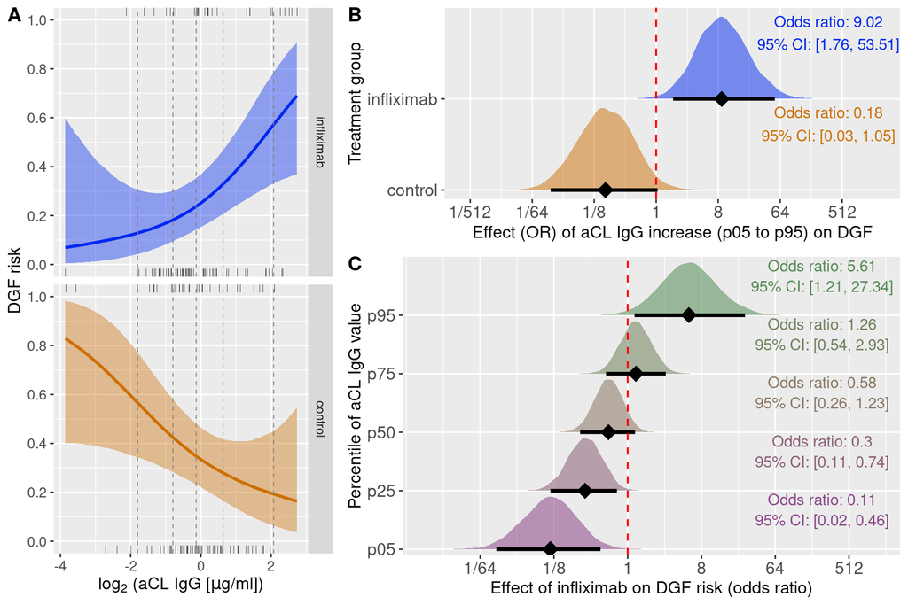

Figure 10: Anti-cardiolipin IgG modulation of the effect of infliximab on delayed graft function (DGF) **after excluding patients with anti-cardiolipin IgG levels above the maximum in the IFX group.** (**A**) Predicted DGF risk by anti-cardiolipin IgG for infliximab (upper) and control (lower) groups, with covariates held at their sample means. Shaded regions represent 95% credible intervals; dashed lines indicate the 5th, 25th, 50th, 75th, and 95th percentiles. (**B**) Posterior distribution of the estimated odds ratio comparing DGF odds at the 95th vs. 5th percentile of anti-cardiolipin IgG. (**C**) Posterior distribution of the effect of infliximab (odds ratio) on DGF across anti-cardiolipin IgG percentiles. Results are from a multivariable Bayesian logistic model with B-splines after data restriction.

```r
plotac <- "sup_figure_2"
path <- "gitignore/figures"


fig <- cowplot::plot_grid(fig_b, fig_c,
  rel_heights = c(0.7, 1),
  labels = c("B", "C"),
  ncol = 1
)

assign(
  plotac,
  cowplot::plot_grid(
    fig_a, fig,
    rel_widths = c(0.6, 1),
    labels = c("A", "")
  )
)

get(plotac)

if (file.exists(paste0(path, "/", plotac)) == FALSE) {
  ggsave(
    path = paste0(path),
    filename = plotac,
    device = "pdf",
    width = 9,
    height = 6
  )
}
```

## 12.2 GFR by GPL_BC

### 12.2.1 Prior

**Open code**

```r
GFR_sd <- sd(data_model_priorImpute$GFR_MDRD_3)
GFR_sd
## [1] 21.17099

priors_interaction_pnl <- c(
  create_prior("Irec_ageM50",
               (2*GFR_sd) / sd(data_sens$rec_age, na.rm = TRUE),
    coef = "Irec_ageM50"),
  create_prior("IHLA_MMM5",
               (2*GFR_sd) / sd(data_sens$HLA_MM, na.rm = TRUE),
    coef = "IHLA_MMM5"),
  create_prior("IKDPIM50",
               (2*GFR_sd) / sd(data_sens$KDPI, na.rm = TRUE),
    coef = "IKDPIM50"),
  create_prior("ICITM15",
               (2*GFR_sd) / sd(data_sens$CIT, na.rm = TRUE),
    coef = "ICITM15"),
  create_prior("male_sex",
    4*GFR_sd,
    coef = "male_sex"),
  create_prior("perfusion_event",
    4*GFR_sd,
    coef = "perfusion_event"),
  create_prior("male_sex_donor",
    4*GFR_sd,
    coef = "male_sex_donor"),

  create_prior("infliximab",
    4*GFR_sd,
    coef = "infliximab"),

 set_prior("student_t(3, 0, 12)", class = "sds",
           coef = 's(GPL_BC_log2, bs = "ps", k = 5)'),

 set_prior("student_t(3, 0, 6)", class = "sds",
           coef = 's(GPL_BC_log2, by = infliximab, bs = "ps", k = 5)'),

  set_prior(paste0("normal(", mean(data_sens$GFR_MDRD_3), ", 200)"),
            class = "Intercept")
)
```

### 12.2.2 Model

**Open code**

```r
model_GFR_MDRD_3_GPL_BC_interaction_NL_sens <- run(
  expr = brm(
    GFR_MDRD_3 ~
    male_sex +
    I(rec_age - 50) +
    male_sex_donor +
    I(KDPI - 50) +
    I(CIT - 15) +
    I(HLA_MM - 5) +
    perfusion_event +
    infliximab +
    s(GPL_BC_log2, bs = 'ps', k = 5) +
    s(GPL_BC_log2, by = infliximab, bs = 'ps', k = 5),
    family = student(),
    data = data_sens,
    prior = priors_interaction_pnl,
    backend = "cmdstanr",
    seed = 2025,
    cores = 4, chains = 4,
    iter = 5000, warmup = 2000,
    control = list(adapt_delta = 0.95)
  ),
  path = "gitignore/run/model_GFR_MDRD_3_GPL_BC_interaction_NL_sens",
  reuse = TRUE
)

summary(model_GFR_MDRD_3_GPL_BC_interaction_NL_sens, robust = TRUE)
##  Family: student
##   Links: mu = identity; sigma = identity; nu = identity
## Formula: GFR_MDRD_3 ~ male_sex + I(rec_age - 50) + male_sex_donor + I(KDPI - 50) + I(CIT - 15) + I(HLA_MM - 5) + perfusion_event + infliximab + s(GPL_BC_log2, bs = "ps", k = 5) + s(GPL_BC_log2, by = infliximab, bs = "ps", k = 5)
##    Data: data_sens (Number of observations: 170)
##   Draws: 4 chains, each with iter = 5000; warmup = 2000; thin = 1;
##          total post-warmup draws = 12000
##
## Smoothing Spline Hyperparameters:
##                               Estimate Est.Error l-95% CI u-95% CI Rhat
## sds(sGPL_BC_log2_1)              11.20      6.61     1.62    34.72 1.00
## sds(sGPL_BC_log2infliximab_1)     3.88      3.51     0.18    16.96 1.00
##                               Bulk_ESS Tail_ESS
## sds(sGPL_BC_log2_1)               6605     4667
## sds(sGPL_BC_log2infliximab_1)     9867     5840
##
## Regression Coefficients:
##                           Estimate Est.Error l-95% CI u-95% CI Rhat Bulk_ESS
## Intercept                    54.48      3.96    46.64    62.36 1.00    12007
## male_sex                      0.41      3.26    -5.97     6.84 1.00    15848
## Irec_ageM50                   0.04      0.15    -0.26     0.34 1.00    13956
## male_sex_donor               -1.93      3.21    -8.21     4.26 1.00    12991
## IKDPIM50                     -0.24      0.08    -0.40    -0.08 1.00    12943
## ICITM15                       0.30      0.21    -0.12     0.73 1.00    13879
## IHLA_MMM5                    -1.31      1.09    -3.48     0.81 1.00    14212
## perfusion_event              -6.06      3.30   -12.45     0.55 1.00    14300
## infliximab                   -0.72     82.88  -163.16   159.97 1.00     5182
## sGPL_BC_log2_1              -15.58     14.08   -48.00    14.59 1.00     8623
## sGPL_BC_log2:infliximab_1    -7.88     56.44  -117.16   101.60 1.00     5192
## sGPL_BC_log2:infliximab_2     7.33     24.27   -39.34    54.80 1.00     5300
##                           Tail_ESS
## Intercept                     9598
## male_sex                      8660
## Irec_ageM50                   8904
## male_sex_donor                9353
## IKDPIM50                      8879
## ICITM15                       8775
## IHLA_MMM5                     8500
## perfusion_event               8473
## infliximab                    6764
## sGPL_BC_log2_1                7794
## sGPL_BC_log2:infliximab_1     6742
## sGPL_BC_log2:infliximab_2     6973
##
## Further Distributional Parameters:
##       Estimate Est.Error l-95% CI u-95% CI Rhat Bulk_ESS Tail_ESS
## sigma    18.48      1.33    15.82    21.18 1.00     9271     8073
## nu       16.67      9.85     5.57    51.30 1.00    10706     8564
##
## Draws were sampled using sample(hmc). For each parameter, Bulk_ESS
## and Tail_ESS are effective sample size measures, and Rhat is the potential
## scale reduction factor on split chains (at convergence, Rhat = 1).
prior_summary(model_GFR_MDRD_3_GPL_BC_interaction_NL_sens)
##                          prior     class
##                         (flat)         b
##    normal(0, 5.95314681980334)         b
##    normal(0, 28.0492387472281)         b
##    normal(0, 2.06314246193193)         b
##    normal(0, 84.6839516288788)         b
##    normal(0, 4.11656184148077)         b
##    normal(0, 84.6839516288788)         b
##    normal(0, 84.6839516288788)         b
##    normal(0, 84.6839516288788)         b
##                         (flat)         b
##                         (flat)         b
##                         (flat)         b
##  normal(51.1232941176471, 200) Intercept
##                  gamma(2, 0.1)        nu
##          student_t(3, 0, 19.5)       sds
##            student_t(3, 0, 12)       sds
##             student_t(3, 0, 6)       sds
##          student_t(3, 0, 19.5)     sigma
##                                               coef group resp dpar nlpar lb ub
##
##                                            ICITM15
##                                          IHLA_MMM5
##                                           IKDPIM50
##                                         infliximab
##                                        Irec_ageM50
##                                           male_sex
##                                     male_sex_donor
##                                    perfusion_event
##                                     sGPL_BC_log2_1
##                          sGPL_BC_log2:infliximab_1
##                          sGPL_BC_log2:infliximab_2
##
##                                                                           1
##                                                                           0
##                   s(GPL_BC_log2, bs = "ps", k = 5)                        0
##  s(GPL_BC_log2, by = infliximab, bs = "ps", k = 5)                        0
##                                                                           0
##        source
##       default
##          user
##          user
##          user
##          user
##          user
##          user
##          user
##          user
##  (vectorized)
##  (vectorized)
##  (vectorized)
##          user
##       default
##       default
##          user
##          user
##       default

tr2 <- round(fixef(model_GFR_MDRD_3_GPL_BC_interaction_NL_sens,
                       robust = TRUE)[-c(1,9:12), c(1,3,4)], 2)

antibody_seq <- quantile(data_sens$GPL_BC_log2,
                         probs = c(0.05, 0.95))

asl <- length(antibody_seq)
quant_dif <- antibody_seq[2] - antibody_seq[1]

data_prediction <- data.frame(
    male_sex = rep(mmale_sex, 2*length(antibody_seq)),
  `male_sex_donor` = rep(mmale_sex_donor, 2*length(antibody_seq)),
  `perfusion_event` = rep(mperfusion_event, 2*length(antibody_seq)),
  `infliximab` = c(rep(0, length(antibody_seq)), rep(1, length(antibody_seq))),
  `rec_age` = rep(mrec_age, 2*length(antibody_seq)),
  `KDPI` = rep(mKDPI, 2*length(antibody_seq)),
  `CIT` = rep(mCIT, 2*length(antibody_seq)),
  `HLA_MM` = rep(mHLA_MM, 2*length(antibody_seq)),
  `GPL_BC_log2` = c(antibody_seq, antibody_seq)
  )

tr <-  posterior_epred(
    model_GFR_MDRD_3_GPL_BC_interaction_NL_sens,
    newdata = data_prediction)

prediction_ctrl <- tr[, c(1:asl)]
prediction_infliximab <- tr[, c((asl+1):(asl*2))]

## get Estimate for infliximab effect across antibody values
prediction <- (
  prediction_infliximab-
     prediction_ctrl
  ) %>% data.frame()

names(prediction) <- c('p05', 'p95')

infliximab_GPL_BC_log2_int <- quantile(
  (prediction$p95 - prediction$p05)/scaling_unit,
         probs = c(0.5, 1/40, 39/40))

tr2 <- rbind(tr2, round(infliximab_GPL_BC_log2_int, 2))
row.names(tr2)[8] <- 'infliximab:GPL_BC_log2'
kableExtra::kable(tr2)
```

Table 27: Results from a multivariable Bayesian robust regression model incorporating a non-linear interaction between anti-cardiolipin IgG (`GPL_BC_log2`) and `infliximab` treatment on estimated glomerular filtration rate (eGFR), **after excluding patients with anti-cardiolipin IgG levels above the maximum in the IFX group** and while accounting for other covariates. `Estimate` represents the estimated change in eGFR per one-unit increase in the predictor. The last row (`infliximab:GPL_BC_log2`) reports the difference in infliximab’s treatment effect at the 95th versus the 5th percentile of anti-cardiolipin IgG, quantifying the interaction effect. `Q2.5` and `Q97.5`: lower and upper bounds of the 95% credible interval, respectively.

|  | Estimate | Q2.5 | Q97.5 |
| --- | --- | --- | --- |
| male_sex | 0.41 | -5.97 | 6.84 |
| Irec_ageM50 | 0.04 | -0.26 | 0.34 |
| male_sex_donor | -1.93 | -8.21 | 4.26 |
| IKDPIM50 | -0.24 | -0.40 | -0.08 |
| ICITM15 | 0.30 | -0.12 | 0.73 |
| IHLA_MMM5 | -1.31 | -3.48 | 0.81 |
| perfusion_event | -6.06 | -12.45 | 0.55 |
| infliximab:GPL_BC_log2 | -16.54 | -36.53 | 3.22 |

### 12.2.3 Visualisation - penalized non-linear effect

Extract posterior draws

**Open code**

```r
antibody_perc <- quantile(data_sens$GPL_BC_log2,
                           probs = c(0, 0.02, 0.05, 0.25, 0.5, 0.75, 0.95, 0.98, 1))

antibody_seq <- seq(antibody_perc[1],
                      antibody_perc[length(antibody_perc)],
                      length.out = 101)

## create prediction
data_prediction <- data.frame(
    male_sex = rep(mmale_sex, 2*length(antibody_seq)),
  `male_sex_donor` = rep(mmale_sex_donor, 2*length(antibody_seq)),
  `perfusion_event` = rep(mperfusion_event, 2*length(antibody_seq)),
  `infliximab` = c(rep(0, length(antibody_seq)), rep(1, length(antibody_seq))),
  `rec_age` = rep(mrec_age, 2*length(antibody_seq)),
  `KDPI` = rep(mKDPI, 2*length(antibody_seq)),
  `CIT` = rep(mCIT, 2*length(antibody_seq)),
  `HLA_MM` = rep(mHLA_MM, 2*length(antibody_seq)),
  `GPL_BC_log2` = c(antibody_seq, antibody_seq)
  )

prediction <- data.frame(
  posterior_epred(
    model_GFR_MDRD_3_GPL_BC_interaction_NL_sens,
    newdata = data_prediction) %>% posterior_summary(
      robust = TRUE
      ) %>% data.frame() %>% select(-Est.Error),
  group = factor(if_else(data_prediction$infliximab == 1, 'infliximab', 'control')),
  GPL_BC_log2 = data_prediction$GPL_BC_log2)
```

Figure A

**Open code**

```r
cole <- c('#CD7006', '#0028F0')

fig_a <- prediction %>%
  mutate(group = factor(group, levels = c("infliximab", "control")),
         `Q2.5` = if_else(`Q2.5` < 0, 0, `Q2.5`)) %>%
  ggplot(aes(x = GPL_BC_log2, y = Estimate, col = group, fill = group)) +
  geom_line(aes(y = Estimate), linewidth = 1) +
  scale_y_continuous(limits = c(0, 125),
                      breaks = c(seq(0, 125, by = 25))) +

  geom_ribbon(aes(ymin = `Q2.5`, ymax = `Q97.5`),
               alpha = 0.4,  color = NA) +

  geom_point(data = data_sens,
             aes(x = GPL_BC_log2, y = GFR_MDRD_3, col = group, fill = group)) +

  labs(x = expression(log[2]~"(aCL IgG ["*mu*"g/ml])"),
       y = "GFR (mL/min/1.73 m²)") +

  scale_color_manual(values = cole,
                       name = "group",
                       breaks = c('control', 'infliximab'),
                       labels = c('control', 'infliximab')) +

  scale_fill_manual(values = cole,
                       name = "group",
                       breaks = c('control', 'infliximab'),
                       labels = c('control', 'infliximab')) +

  facet_grid(rows = vars(group)) +

  theme(axis.text=element_text(size = 10),
        axis.title=element_text(size = 12),
        strip.text.x = element_text(size = 12),
        legend.position = "none") +

  geom_vline(xintercept = antibody_perc[3:7], linetype = 2,
                            color = "grey50", size = 0.3)
```

Figure B

**Open code**

```r
antibody_seq <- antibody_perc[c(3, 7)]
antibody_seq
##        5%       95%
## -1.801712  2.071126

data_prediction <- data.frame(
   male_sex = rep(mmale_sex, 2*length(antibody_seq)),
  `male_sex_donor` = rep(mmale_sex_donor, 2*length(antibody_seq)),
  `perfusion_event` = rep(mperfusion_event, 2*length(antibody_seq)),
  `infliximab` = c(rep(0, length(antibody_seq)), rep(1, length(antibody_seq))),
  `rec_age` = rep(mrec_age, 2*length(antibody_seq)),
  `KDPI` = rep(mKDPI, 2*length(antibody_seq)),
  `CIT` = rep(mCIT, 2*length(antibody_seq)),
  `HLA_MM` = rep(mHLA_MM, 2*length(antibody_seq)),
  `GPL_BC_log2` = c(antibody_seq, antibody_seq)
  )

tr <-  posterior_epred(
    model_GFR_MDRD_3_GPL_BC_interaction_NL_sens,
    newdata = data_prediction)

tr_ctrl <- (tr[,c(ncol(tr)/2)] - tr[,c(1)])
tr_infliximab <- (tr[,c(ncol(tr))] - tr[,c(ncol(tr)/2)+1])

post_fix <- data.frame(
  b_GPL_BC_log2 = tr_ctrl,
  b_GPL_BC_log2_infliximab = tr_infliximab
)

tr <- post_fix %>%
  mutate(control = b_GPL_BC_log2,
         infliximab = b_GPL_BC_log2_infliximab) %>%
  select(control, infliximab) %>%
  data.frame()

CIS <- sapply(
  tr,
  function(p) quantile(p, probs = c(1/40, 39/40, 0.5, 1e-3, 1-1e-3))
  ) %>%
  round(1)

CIS
##       control infliximab
## 2.5%     -9.0      -23.8
## 97.5%    20.5        2.3
## 50%       5.7      -10.7
## 0.1%    -18.8      -31.8
## 99.9%    30.6        9.0

xpos <- 39.2

fig_b <- tr %>%
  pivot_longer(values_to = 'value',
               cols = c('control', 'infliximab'),
               names_to = 'group') %>%
  ggplot(aes(x = value, y = group, fill = group)) +

  stat_halfeye(.width = c(0.95), slab_alpha=0.5,
               linewidth = 5,
               shape = 18,
               point_size = 5,
               normalize = "groups",
               p_limits = c(1e-3, 1-1e-3)) +

    labs(x = 'Effect of aCL IgG increase (p05 to p95) on eGFR',
         y = 'Treatment group') +

  scale_fill_manual(values = cole,
                       name = "Treatment group",
                       breaks = c('control', 'infliximab'),
                       labels = c('control', 'infliximab')) +

  scale_y_discrete(expand = expansion(add = 0.1)) +
  coord_cartesian(xlim = c(-50, 52)) +

  geom_vline(xintercept = 0, linetype = 2,
                color = "red", size = 0.6) +

  theme(axis.text = element_text(size = 12),
        axis.title = element_text(size = 12)) +

  theme(legend.position = "none") +

  annotate("text",  x = xpos, y = 2.85 ,
           label = paste0("Estimate: ", CIS[3,2]),
           color = cole[2] ) +

  annotate("text",  x = xpos, y = 1.85 ,
           label = paste0("Estimate: ", CIS[3,1]),
           color = cole[1] ) +

  annotate("text",  x = xpos, y = 2.6 ,
           label = paste0("95% CI: [", CIS[1,2], ", ", CIS[2,2], "]"),
           color = cole[2] ) +

  annotate("text",  x = xpos, y = 1.6 ,
           label = paste0("95% CI: [", CIS[1,1], ", ", CIS[2,1], "]"),
           color = cole[1] )
```

Figure C

**Open code**

```r
cole <- c("#8B4789", "#8B5F77", "#8B7765", "#6F815C", "#548B54")
xpos <- 30

antibody_seq <- antibody_perc[c(3, 4, 5, 6, 7)]

asl <- length(antibody_seq)

data_prediction <- data.frame(
    male_sex = rep(mmale_sex, 2*length(antibody_seq)),
  `male_sex_donor` = rep(mmale_sex_donor, 2*length(antibody_seq)),
  `perfusion_event` = rep(mperfusion_event, 2*length(antibody_seq)),
  `infliximab` = c(rep(0, length(antibody_seq)), rep(1, length(antibody_seq))),
  `rec_age` = rep(mrec_age, 2*length(antibody_seq)),
  `KDPI` = rep(mKDPI, 2*length(antibody_seq)),
  `CIT` = rep(mCIT, 2*length(antibody_seq)),
  `HLA_MM` = rep(mHLA_MM, 2*length(antibody_seq)),
  `GPL_BC_log2` = c(antibody_seq, antibody_seq)
  )

tr <-  posterior_epred(
    model_GFR_MDRD_3_GPL_BC_interaction_NL_sens,
    newdata = data_prediction)

prediction_ctrl <- tr[, c(1:asl)]

prediction_infliximab <- tr[, c((asl+1):(asl*2))]

prediction <- (
  prediction_infliximab-
     prediction_ctrl
  ) %>% data.frame()


names(prediction) <- c('p05', 'p25', 'p50', 'p75', 'p95')

CIS <- sapply(
  prediction,
  function(p) quantile(p, probs = c(1/40, 39/40, 0.5, 1e-3, 1-1e-3))
  ) %>%
  round(1)

CIS
##         p05   p25   p50   p75   p95
## 2.5%   -5.0  -5.6  -7.4 -11.4 -23.5
## 97.5%  17.4   9.4   5.5   2.7   2.4
## 50%     6.2   1.9  -0.9  -4.2 -10.3
## 0.1%  -11.3 -10.4 -11.8 -16.0 -30.6
## 99.9%  23.9  13.8   9.1   6.9  10.2

fig_c <- prediction %>%
  pivot_longer(values_to = 'value',
               cols = c('p05', 'p25', 'p50', 'p75', 'p95'),
               names_to = 'GPL_BC_percentile') %>%

  ggplot(aes(y = GPL_BC_percentile, x = value, fill = GPL_BC_percentile)) +

  stat_halfeye(.width = c(0.95), slab_alpha = 0.55,
               linewidth = 5,
               shape = 18,
               point_size = 5,
               normalize = "groups",
               p_limits = c(1e-3, 1-1e-3)) +

  labs(x = "Effect of infliximab on GFR (mL/min/1.73 m²)",
         y = 'Percentile of aCL IgG value') +

  scale_fill_manual(values = cole,
                       name = "Percentile of aCL IgG value",
                       breaks = c('p05', 'p25', 'p50', 'p75', 'p95'),
                       labels = c('p05', 'p25', 'p50', 'p75', 'p95')) +

  coord_cartesian(xlim = c(-40, 40)) +
  scale_y_discrete(expand = expansion(add = 0.1)) +


  geom_vline(xintercept = 0, linetype = 2,
                color = "red", size = 0.6) +

  theme(axis.text = element_text(size = 12),
        axis.title = element_text(size = 12)) +

  theme(legend.position = "none") +


  annotate("text",  x = xpos, y = 5.85 ,
           label = paste0("Estimate: ", CIS[3,5]),
           color = cole[5] ) +

  annotate("text",  x = xpos, y = 4.85,
           label = paste0("Estimate: ", CIS[3,4]),
           color = cole[4] ) +

  annotate("text",  x = xpos, y = 3.85,
           label = paste0("Estimate: ", CIS[3,3]),
           color = cole[3] ) +

  annotate("text",  x = xpos, y = 2.85,
           label = paste0("Estimate: ", CIS[3,2]),
           color = cole[2] ) +

  annotate("text",  x = xpos, y = 1.85,
           label = paste0("Estimate: ", CIS[3,1]),
           color = cole[1] ) +

  annotate("text",  x = xpos, y = 5.5 ,
           label = paste0("95% CI: [", CIS[1,5], ", ", CIS[2,5], "]"),
           color = cole[5] ) +

  annotate("text",  x = xpos, y = 4.5 ,
           label = paste0("95% CI: [", CIS[1,4], ", ", CIS[2,4], "]"),
           color = cole[4] ) +

  annotate("text",  x = xpos, y = 3.5 ,
           label = paste0("95% CI: [", CIS[1,3], ", ", CIS[2,3], "]"),
           color = cole[3] ) +

  annotate("text",  x = xpos, y = 2.5 ,
           label = paste0("95% CI: [", CIS[1,2], ", ", CIS[2,2], "]"),
           color = cole[2] ) +

  annotate("text",  x = xpos, y = 1.5 ,
           label = paste0("95% CI: [", CIS[1,1], ", ", CIS[2,1], "]"),
           color = cole[1] )
```

#### 12.2.3.1 Figure merged

**Open code**

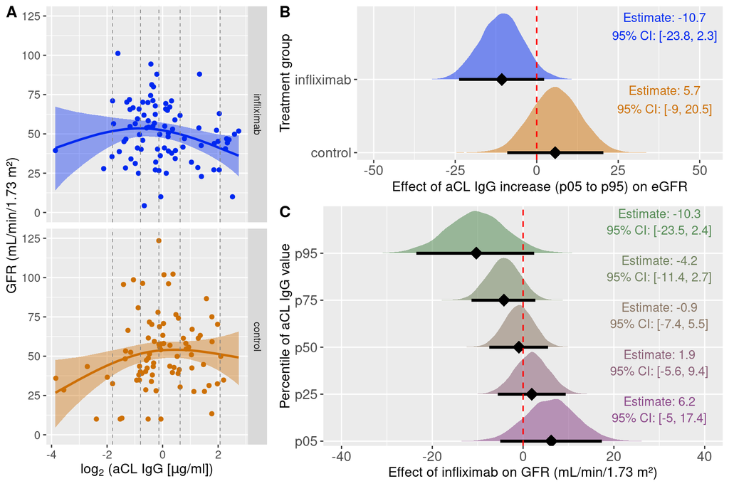

Figure 11: *Supplementary Figure 6*: **Anti-cardiolipin IgG modulation of the infliximab effect on estimated glomerula filtration rate (eGFR) after excluding patients with anti-cardiolipin IgG levels above the maximum in the IFX group.** (**A**) Predicted eGFR by anti-cardiolipin IgG for infliximab (upper) and control (lower) groups, with covariates held at their sample means. Shaded regions represent 95% credible intervals; dashed lines indicate the 5th, 25th, 50th, 75th, and 95th percentiles of cardiolipin levels. (**B**) Posterior distribution of the estimated change in eGFR when anti-cardiolipin IgG increases from the 5th to the 95th sample percentile. (**C**) Posterior distribution of the effect of infliximab on eGFR across anti-cardiolipin IgG percentiles. Results are from a multivariable Bayesian robust regression with B-splines after data restriction.

```r
plotac <- 'sup_figure_6'
path <- "gitignore/figures"


fig <- cowplot::plot_grid(fig_b, fig_c,
  rel_heights = c(0.7, 1),
  labels = c("B", "C"),
  ncol = 1
)

assign(
  plotac,
  cowplot::plot_grid(
    fig_a, fig,
    rel_widths = c(0.6, 1),
    labels = c("A", "")
  )
)

get(plotac)

if (file.exists(paste0(path, "/", plotac)) == FALSE) {
  ggsave(
    path = paste0(path),
    filename = plotac,
    device = "pdf",
    width = 9,
    height = 6
  )
}
```

# 13 DGF Subgroup analysis by `GPL_BC`

We will use data divided to patients with under- and above-median value of aCL IgG (`GPL_BC`)

## 13.1 Define priors

**Open code**

```r
priors_subset <- c(

  create_prior("GPL_BC_log2",
    2 / sd(data_model_priorImpute$GPL_BC_log2, na.rm = TRUE),
    coef = "GPL_BC_log2"
  ),
   create_prior("IHLA_MMM5",
    2 / sd(data_model_priorImpute$HLA_MM, na.rm = TRUE),
    coef = "IHLA_MMM5"
  ),
  create_prior("IKDPIM50",
    2 / sd(data_model_priorImpute$KDPI, na.rm = TRUE),
    coef = "IKDPIM50"
  ),
  create_prior("Irec_ageM50",
    2 / sd(data_model_priorImpute$rec_age, na.rm = TRUE),
    coef = "Irec_ageM50"
),
  create_prior("ICITM15",
    2 / sd(data_model_priorImpute$CIT, na.rm = TRUE),
    coef = "ICITM15"
  ),
  create_prior("male_sex",
    4,
    coef = "male_sex"
  ),
  create_prior("perfusion_event",
    4,
    coef = "perfusion_event"
  ),
  create_prior("male_sex_donor",
    4,
    coef = "male_sex_donor"
  ),
  create_prior("infliximab",
    4,
    coef = "infliximab"
  ),
  set_prior(paste0("normal(", logit(mean(data_model_priorImpute$DGF)), ", 10)"),
    class = "Intercept"
  )
)
```

## 13.2 Fit model for $<$ median aCL IgG level

**Open code**

```r
model_dgf_GPL_BC_lowGPLBC <- run(
  expr = brm(
    DGF ~
      male_sex +
      I(rec_age - 50) +
      male_sex_donor +
      I(KDPI - 50) +
      I(CIT - 15) +
      I(HLA_MM - 5) +
      perfusion_event +
      infliximab +
      GPL_BC_log2,
    family = bernoulli(),
    data = data_imputed_lowGPL,
    prior = priors_subset,
    backend = "cmdstanr",
    seed = 2025,
    cores = 4, chains = 4,
    iter = 4000, warmup = 2000,
    control = list(adapt_delta = 0.95)
  ),
  path = "gitignore/run/model_dgf_GPL_BC_lowGPLBC",
  reuse = TRUE
)

summary(model_dgf_GPL_BC_lowGPLBC, robust = TRUE)
##  Family: bernoulli
##   Links: mu = logit
## Formula: DGF ~ male_sex + I(rec_age - 50) + male_sex_donor + I(KDPI - 50) + I(CIT - 15) + I(HLA_MM - 5) + perfusion_event + infliximab + GPL_BC_log2
##    Data: data_imputed_lowGPL (Number of observations: 88)
##   Draws: 4 chains, each with iter = 4000; warmup = 2000; thin = 1;
##          total post-warmup draws = 8000
##
## Regression Coefficients:
##                 Estimate Est.Error l-95% CI u-95% CI Rhat Bulk_ESS Tail_ESS
## Intercept          -1.15      0.88    -2.92     0.57 1.00     6103     5642
## male_sex            0.66      0.61    -0.50     1.88 1.00     7547     5709
## Irec_ageM50        -0.00      0.03    -0.05     0.05 1.00     7614     6063
## male_sex_donor      0.63      0.56    -0.53     1.77 1.00     7908     5889
## IKDPIM50            0.00      0.01    -0.03     0.03 1.00     6795     5914
## ICITM15             0.08      0.04    -0.00     0.16 1.00     7322     6440
## IHLA_MMM5           0.26      0.20    -0.12     0.67 1.00     6960     6236
## perfusion_event    -0.43      0.58    -1.61     0.69 1.00     7869     6343
## infliximab         -1.55      0.57    -2.74    -0.45 1.00     6379     5667
## GPL_BC_log2        -0.49      0.35    -1.22     0.18 1.00     7280     6096
##
## Draws were sampled using sample(hmc). For each parameter, Bulk_ESS
## and Tail_ESS are effective sample size measures, and Rhat is the potential
## scale reduction factor on split chains (at convergence, Rhat = 1).
prior_summary(model_dgf_GPL_BC_lowGPLBC)
##                           prior     class            coef group resp dpar nlpar
##                          (flat)         b
##     normal(0, 1.41170525720746)         b     GPL_BC_log2
##    normal(0, 0.280307006032291)         b         ICITM15
##     normal(0, 1.38219051128263)         b       IHLA_MMM5
##   normal(0, 0.0970980394231448)         b        IKDPIM50
##                    normal(0, 4)         b      infliximab
##    normal(0, 0.190589762164436)         b     Irec_ageM50
##                    normal(0, 4)         b        male_sex
##                    normal(0, 4)         b  male_sex_donor
##                    normal(0, 4)         b perfusion_event
##  normal(-0.667829372575656, 10) Intercept
##  lb ub  source
##        default
##           user
##           user
##           user
##           user
##           user
##           user
##           user
##           user
##           user
##           user

tr <- round(exp(fixef(model_dgf_GPL_BC_lowGPLBC, robust = TRUE)[-1, c(1,3,4)]), 2)
colnames(tr)[1] <- 'OR'
kableExtra::kable(tr)
```

Table 28: Results from multivariable Bayesian logistic regression models examining the main effects of predictors, including `infliximab` treatment and log2-transformed anti-cardiolipin IgG (`GPL_BC_log2`), on delayed graft function (`DGF`), without interaction terms and **including only patients with anti-cardiolipin IgG level below median**. The odds ratio (OR) represents the estimated change in the odds of DGF per one-unit increase in the predictor. `OR`: odds ratio; `Q2.5` and `Q97.5`: lower and upper bounds of the 95% credible interval, respectively.

|  | OR | Q2.5 | Q97.5 |
| --- | --- | --- | --- |
| male_sex | 1.94 | 0.61 | 6.59 |
| Irec_ageM50 | 1.00 | 0.95 | 1.05 |
| male_sex_donor | 1.87 | 0.59 | 5.88 |
| IKDPIM50 | 1.00 | 0.97 | 1.03 |
| ICITM15 | 1.08 | 1.00 | 1.18 |
| IHLA_MMM5 | 1.30 | 0.89 | 1.96 |
| perfusion_event | 0.65 | 0.20 | 2.00 |
| infliximab | 0.21 | 0.06 | 0.64 |
| GPL_BC_log2 | 0.61 | 0.29 | 1.20 |

## 13.3 Fit model for aCL $\geq$ median

**Open code**

```r
model_dgf_GPL_BC_highGPLBC <- run(
  expr = brm(
    DGF ~
      male_sex +
      I(rec_age - 50) +
      male_sex_donor +
      I(KDPI - 50) +
      I(CIT - 15) +
      I(HLA_MM - 5) +
      perfusion_event +
      infliximab +
      GPL_BC_log2,
    family = bernoulli(),
    data = data_imputed_highGPL,
    prior = priors_subset,
    backend = "cmdstanr",
    seed = 2025,
    cores = 4, chains = 4,
    iter = 4000, warmup = 2000,
    control = list(adapt_delta = 0.95)
  ),
  path = "gitignore/run/model_dgf_GPL_BC_highGPLBC",
  reuse = TRUE
)

summary(model_dgf_GPL_BC_highGPLBC, robust = TRUE)
##  Family: bernoulli
##   Links: mu = logit
## Formula: DGF ~ male_sex + I(rec_age - 50) + male_sex_donor + I(KDPI - 50) + I(CIT - 15) + I(HLA_MM - 5) + perfusion_event + infliximab + GPL_BC_log2
##    Data: data_imputed_highGPL (Number of observations: 89)
##   Draws: 4 chains, each with iter = 4000; warmup = 2000; thin = 1;
##          total post-warmup draws = 8000
##
## Regression Coefficients:
##                 Estimate Est.Error l-95% CI u-95% CI Rhat Bulk_ESS Tail_ESS
## Intercept          -2.17      0.82    -3.90    -0.66 1.00     5958     5518
## male_sex            1.56      0.59     0.44     2.78 1.00     6964     5785
## Irec_ageM50        -0.04      0.02    -0.09     0.01 1.00     7544     6006
## male_sex_donor      0.31      0.58    -0.82     1.46 1.00     7261     6549
## IKDPIM50            0.02      0.01    -0.00     0.05 1.00     6958     6417
## ICITM15             0.08      0.04     0.01     0.16 1.00     7101     5523
## IHLA_MMM5           0.33      0.20    -0.05     0.74 1.00     6725     5730
## perfusion_event    -0.96      0.61    -2.22     0.20 1.00     6888     5602
## infliximab          1.06      0.55     0.00     2.16 1.00     7743     6408
## GPL_BC_log2         0.33      0.25    -0.16     0.84 1.00     7068     6138
##
## Draws were sampled using sample(hmc). For each parameter, Bulk_ESS
## and Tail_ESS are effective sample size measures, and Rhat is the potential
## scale reduction factor on split chains (at convergence, Rhat = 1).
prior_summary(model_dgf_GPL_BC_highGPLBC)
##                           prior     class            coef group resp dpar nlpar
##                          (flat)         b
##     normal(0, 1.41170525720746)         b     GPL_BC_log2
##    normal(0, 0.280307006032291)         b         ICITM15
##     normal(0, 1.38219051128263)         b       IHLA_MMM5
##   normal(0, 0.0970980394231448)         b        IKDPIM50
##                    normal(0, 4)         b      infliximab
##    normal(0, 0.190589762164436)         b     Irec_ageM50
##                    normal(0, 4)         b        male_sex
##                    normal(0, 4)         b  male_sex_donor
##                    normal(0, 4)         b perfusion_event
##  normal(-0.667829372575656, 10) Intercept
##  lb ub  source
##        default
##           user
##           user
##           user
##           user
##           user
##           user
##           user
##           user
##           user
##           user

tr <- round(exp(fixef(model_dgf_GPL_BC_highGPLBC, robust = TRUE)[-1, c(1,3,4)]), 3)
colnames(tr)[1] <- 'Odds ratio'
kableExtra::kable(tr)
```

Table 29: Results from multivariable Bayesian logistic regression models examining the main effects of predictors, including `infliximab` treatment and log2-transformed anti-cardiolipin IgG (`GPL_BC_log2`), on delayed graft function (`DGF`), without interaction terms and **including only patients with anti-cardiolipin IgG level at/above median**. The odds ratio (OR) represents the estimated change in the odds of DGF per one-unit increase in the predictor. `OR`: odds ratio; `Q2.5` and `Q97.5`: lower and upper bounds of the 95% credible interval, respectively.

|  | Odds ratio | Q2.5 | Q97.5 |
| --- | --- | --- | --- |
| male_sex | 4.754 | 1.548 | 16.143 |
| Irec_ageM50 | 0.964 | 0.918 | 1.012 |
| male_sex_donor | 1.361 | 0.440 | 4.314 |
| IKDPIM50 | 1.024 | 0.996 | 1.055 |
| ICITM15 | 1.083 | 1.008 | 1.179 |
| IHLA_MMM5 | 1.387 | 0.950 | 2.098 |
| perfusion_event | 0.382 | 0.108 | 1.218 |
| infliximab | 2.897 | 1.005 | 8.695 |
| GPL_BC_log2 | 1.397 | 0.855 | 2.324 |

# 14 Models eGFR with at least 480 days of FU with graft functioning

**Open code**

```r
data_sens2 <- data_first %>%
  filter(
    GFR_days_2 >= 480 | death_event == 1 | graft_failure == 1
      ) %>%
  mutate(group = factor(if_else(infliximab == 1, 'infliximab', 'control')))

dim(data_sens2)
## [1] 154  33
```

## 14.1 by GPL_BC

### 14.1.1 Prior

**Open code**

```r
GFR_sd <- sd(data_sens2$GFR_MDRD_3)
GFR_sd
## [1] 19.93074

priors_interaction_pnl <- c(
  create_prior("Irec_ageM50",
               (2*GFR_sd) / sd(data_sens2$rec_age, na.rm = TRUE),
    coef = "Irec_ageM50"),

  create_prior("IHLA_MMM5",
               (2*GFR_sd) / sd(data_sens2$HLA_MM, na.rm = TRUE),
    coef = "IHLA_MMM5"),

  create_prior("IKDPIM50",
               (2*GFR_sd) / sd(data_sens2$KDPI, na.rm = TRUE),
    coef = "IKDPIM50"),

  create_prior("ICITM15",
               (2*GFR_sd) / sd(data_sens2$CIT, na.rm = TRUE),
    coef = "ICITM15"),

  create_prior("male_sex",
    4*GFR_sd,
    coef = "male_sex"),

  create_prior("perfusion_event",
    4*GFR_sd,
    coef = "perfusion_event"),

  create_prior("male_sex_donor",
    4*GFR_sd,
    coef = "male_sex_donor"),

  create_prior("infliximab",
    4*GFR_sd,
    coef = "infliximab"),

 set_prior("student_t(3, 0, 12)", class = "sds",
           coef = 's(GPL_BC_log2, bs = "ps", k = 5)'),

 set_prior("student_t(3, 0, 6)", class = "sds",
           coef = 's(GPL_BC_log2, by = infliximab, bs = "ps", k = 5)'),

  set_prior(paste0("normal(", mean(data_sens2$GFR_MDRD_3), ", 200)"),
            class = "Intercept")
)
```

### 14.1.2 Model

**Open code**

```r
model_GFR_MDRD_3_GPL_BC_interaction_NL_sens2 <- run(
  expr = brm(
    GFR_MDRD_3 ~
    male_sex +
    I(rec_age - 50) +
    male_sex_donor +
    I(KDPI - 50) +
    I(CIT - 15) +
    I(HLA_MM - 5) +
    perfusion_event +
    infliximab +
    s(GPL_BC_log2, bs = 'ps', k = 5) +
    s(GPL_BC_log2, by = infliximab, bs = 'ps', k = 5),
    family = student(),
    data = data_sens2,
    prior = priors_interaction_pnl,
    backend = "cmdstanr",
    seed = 2025,
    cores = 4, chains = 4,
    iter = 5000, warmup = 2000,
    control = list(adapt_delta = 0.95)
  ),
  path = "gitignore/run/model_GFR_MDRD_3_GPL_BC_interaction_NL_sens2",
  reuse = TRUE
)

summary(model_GFR_MDRD_3_GPL_BC_interaction_NL_sens2, robust = TRUE)
##  Family: student
##   Links: mu = identity; sigma = identity; nu = identity
## Formula: GFR_MDRD_3 ~ male_sex + I(rec_age - 50) + male_sex_donor + I(KDPI - 50) + I(CIT - 15) + I(HLA_MM - 5) + perfusion_event + infliximab + s(GPL_BC_log2, bs = "ps", k = 5) + s(GPL_BC_log2, by = infliximab, bs = "ps", k = 5)
##    Data: data_sens2 (Number of observations: 154)
##   Draws: 4 chains, each with iter = 5000; warmup = 2000; thin = 1;
##          total post-warmup draws = 12000
##
## Smoothing Spline Hyperparameters:
##                               Estimate Est.Error l-95% CI u-95% CI Rhat
## sds(sGPL_BC_log2_1)              12.04      7.29     1.37    36.66 1.00
## sds(sGPL_BC_log2infliximab_1)     4.12      3.89     0.17    19.70 1.00
##                               Bulk_ESS Tail_ESS
## sds(sGPL_BC_log2_1)               5502     3578
## sds(sGPL_BC_log2infliximab_1)    10206     5052
##
## Regression Coefficients:
##                           Estimate Est.Error l-95% CI u-95% CI Rhat Bulk_ESS
## Intercept                    55.76      4.06    47.63    63.70 1.00    13224
## male_sex                     -1.06      3.33    -7.56     5.51 1.00    14555
## Irec_ageM50                   0.05      0.15    -0.25     0.35 1.00    14540
## male_sex_donor               -2.57      3.37    -9.26     4.05 1.00    13238
## IKDPIM50                     -0.29      0.08    -0.45    -0.12 1.00    13489
## ICITM15                       0.29      0.22    -0.15     0.71 1.00    14845
## IHLA_MMM5                    -1.23      1.11    -3.43     0.90 1.00    13879
## perfusion_event              -3.56      3.30   -10.19     2.95 1.00    14153
## infliximab                   -0.24     77.61  -152.88   148.64 1.00     5557
## sGPL_BC_log2_1                9.25     16.77   -26.48    50.93 1.00     9004
## sGPL_BC_log2:infliximab_1   -13.97     44.82  -100.82    73.77 1.00     5580
## sGPL_BC_log2:infliximab_2     9.71     28.48   -44.52    65.44 1.00     5760
##                           Tail_ESS
## Intercept                     9055
## male_sex                      7481
## Irec_ageM50                   9607
## male_sex_donor                8737
## IKDPIM50                      9901
## ICITM15                       9479
## IHLA_MMM5                     9397
## perfusion_event               9125
## infliximab                    6824
## sGPL_BC_log2_1                6562
## sGPL_BC_log2:infliximab_1     6926
## sGPL_BC_log2:infliximab_2     6841
##
## Further Distributional Parameters:
##       Estimate Est.Error l-95% CI u-95% CI Rhat Bulk_ESS Tail_ESS
## sigma    17.96      1.25    15.50    20.51 1.00    11959     8561
## nu       21.30     12.37     6.57    61.21 1.00    12525     7831
##
## Draws were sampled using sample(hmc). For each parameter, Bulk_ESS
## and Tail_ESS are effective sample size measures, and Rhat is the potential
## scale reduction factor on split chains (at convergence, Rhat = 1).
prior_summary(model_GFR_MDRD_3_GPL_BC_interaction_NL_sens2)
##                          prior     class
##                         (flat)         b
##    normal(0, 5.48898844779997)         b
##    normal(0, 25.9053313823118)         b
##    normal(0, 1.95751635259431)         b
##    normal(0, 79.7229697409756)         b
##    normal(0, 3.82892016085826)         b
##    normal(0, 79.7229697409756)         b
##    normal(0, 79.7229697409756)         b
##    normal(0, 79.7229697409756)         b
##                         (flat)         b
##                         (flat)         b
##                         (flat)         b
##  normal(51.4243506493507, 200) Intercept
##                  gamma(2, 0.1)        nu
##          student_t(3, 0, 18.2)       sds
##            student_t(3, 0, 12)       sds
##             student_t(3, 0, 6)       sds
##          student_t(3, 0, 18.2)     sigma
##                                               coef group resp dpar nlpar lb ub
##
##                                            ICITM15
##                                          IHLA_MMM5
##                                           IKDPIM50
##                                         infliximab
##                                        Irec_ageM50
##                                           male_sex
##                                     male_sex_donor
##                                    perfusion_event
##                                     sGPL_BC_log2_1
##                          sGPL_BC_log2:infliximab_1
##                          sGPL_BC_log2:infliximab_2
##
##                                                                           1
##                                                                           0
##                   s(GPL_BC_log2, bs = "ps", k = 5)                        0
##  s(GPL_BC_log2, by = infliximab, bs = "ps", k = 5)                        0
##                                                                           0
##        source
##       default
##          user
##          user
##          user
##          user
##          user
##          user
##          user
##          user
##  (vectorized)
##  (vectorized)
##  (vectorized)
##          user
##       default
##       default
##          user
##          user
##       default

tr2 <- round(fixef(model_GFR_MDRD_3_GPL_BC_interaction_NL_sens2,
                       robust = TRUE)[-c(1,9:12), c(1,3,4)], 2)

antibody_seq <- quantile(data_sens2$GPL_BC_log2,
                         probs = c(0.05, 0.95))

asl <- length(antibody_seq)
quant_dif <- antibody_seq[2] - antibody_seq[1]

data_prediction <- data.frame(
    male_sex = rep(mmale_sex, 2*length(antibody_seq)),
  `male_sex_donor` = rep(mmale_sex_donor, 2*length(antibody_seq)),
  `perfusion_event` = rep(mperfusion_event, 2*length(antibody_seq)),
  `infliximab` = c(rep(0, length(antibody_seq)), rep(1, length(antibody_seq))),
  `rec_age` = rep(mrec_age, 2*length(antibody_seq)),
  `KDPI` = rep(mKDPI, 2*length(antibody_seq)),
  `CIT` = rep(mCIT, 2*length(antibody_seq)),
  `HLA_MM` = rep(mHLA_MM, 2*length(antibody_seq)),
  `GPL_BC_log2` = c(antibody_seq, antibody_seq)
  )

tr <-  posterior_epred(
    model_GFR_MDRD_3_GPL_BC_interaction_NL_sens2,
    newdata = data_prediction)

prediction_ctrl <- tr[, c(1:asl)]
prediction_infliximab <- tr[, c((asl+1):(asl*2))]

## get Estimate for infliximab effect across antibody values
prediction <- (
  prediction_infliximab-
     prediction_ctrl
  ) %>% data.frame()

names(prediction) <- c('p05', 'p95')

infliximab_GPL_BC_log2_int <- quantile(
  (prediction$p95 - prediction$p05)/scaling_unit,
         probs = c(0.5, 1/40, 39/40))

tr2 <- rbind(tr2, round(infliximab_GPL_BC_log2_int, 2))
row.names(tr2)[8] <- 'infliximab:GPL_BC_log2'
kableExtra::kable(tr2)
```

Table 30: Results from a multivariable Bayesian robust regression model incorporating a non-linear interaction between anti-cardiolipin IgG (`GPL_BC_log2`) and `infliximab` treatment on estimated glomerular filtration rate (eGFR), **after excluding patients which were lost during follow-up before 480th day post TX** and while accounting for other covariates. `Estimate` represents the estimated change in eGFR per one-unit increase in the predictor. The last row (`infliximab:GPL_BC_log2`) reports the difference in infliximab’s treatment effect at the 95th versus the 5th percentile of anti-cardiolipin IgG, quantifying the interaction effect. `Q2.5` and `Q97.5`: lower and upper bounds of the 95% credible interval, respectively.

|  | Estimate | Q2.5 | Q97.5 |
| --- | --- | --- | --- |
| male_sex | -1.06 | -7.56 | 5.51 |
| Irec_ageM50 | 0.05 | -0.25 | 0.35 |
| male_sex_donor | -2.57 | -9.26 | 4.05 |
| IKDPIM50 | -0.29 | -0.45 | -0.12 |
| ICITM15 | 0.29 | -0.15 | 0.71 |
| IHLA_MMM5 | -1.23 | -3.43 | 0.90 |
| perfusion_event | -3.56 | -10.19 | 2.95 |
| infliximab:GPL_BC_log2 | -17.76 | -37.37 | 1.55 |

### 14.1.3 Visualisation - penalized non-linear effect

Extract posterior draws

**Open code**

```r
antibody_perc <- quantile(data_sens2$GPL_BC_log2,
                           probs = c(0, 0.02, 0.05, 0.25, 0.5, 0.75, 0.95, 0.98, 1))

antibody_seq <- seq(antibody_perc[1],
                      antibody_perc[length(antibody_perc)],
                      length.out = 101)

## create prediction
data_prediction <- data.frame(
    male_sex = rep(mmale_sex, 2*length(antibody_seq)),
  `male_sex_donor` = rep(mmale_sex_donor, 2*length(antibody_seq)),
  `perfusion_event` = rep(mperfusion_event, 2*length(antibody_seq)),
  `infliximab` = c(rep(0, length(antibody_seq)), rep(1, length(antibody_seq))),
  `rec_age` = rep(mrec_age, 2*length(antibody_seq)),
  `KDPI` = rep(mKDPI, 2*length(antibody_seq)),
  `CIT` = rep(mCIT, 2*length(antibody_seq)),
  `HLA_MM` = rep(mHLA_MM, 2*length(antibody_seq)),
  `GPL_BC_log2` = c(antibody_seq, antibody_seq)
  )

prediction <- data.frame(
  posterior_epred(
    model_GFR_MDRD_3_GPL_BC_interaction_NL_sens2,
    newdata = data_prediction) %>% posterior_summary(
      robust = TRUE
      ) %>% data.frame() %>% select(-Est.Error),
  group = factor(if_else(data_prediction$infliximab == 1, 'infliximab', 'control')),
  GPL_BC_log2 = data_prediction$GPL_BC_log2)
```

Figure A

**Open code**

```r
cole <- c('#CD7006', '#0028F0')

fig_a <- prediction %>%
  mutate(group = factor(group, levels = c("infliximab", "control")),
         `Q2.5` = if_else(`Q2.5` < 0, 0, `Q2.5`)) %>%
  ggplot(aes(x = GPL_BC_log2, y = Estimate, col = group, fill = group)) +
  geom_line(aes(y = Estimate), linewidth = 1) +
  scale_y_continuous(limits = c(0, 125),
                      breaks = c(seq(0, 125, by = 25))) +

  geom_ribbon(aes(ymin = `Q2.5`, ymax = `Q97.5`),
               alpha = 0.4,  color = NA) +

  geom_point(data = data_sens2,
             aes(x = GPL_BC_log2, y = GFR_MDRD_3, col = group, fill = group)) +

  labs(x = expression(log[2]~"(aCL IgG ["*mu*"g/ml])"),
       y = "GFR (mL/min/1.73 m²)") +

  scale_color_manual(values = cole,
                       name = "group",
                       breaks = c('control', 'infliximab'),
                       labels = c('control', 'infliximab')) +

  scale_fill_manual(values = cole,
                       name = "group",
                       breaks = c('control', 'infliximab'),
                       labels = c('control', 'infliximab')) +

  facet_grid(rows = vars(group)) +

  theme(axis.text=element_text(size = 10),
        axis.title=element_text(size = 12),
        strip.text.x = element_text(size = 12),
        legend.position = "none") +

  geom_vline(xintercept = antibody_perc[3:7], linetype = 2,
                            color = "grey50", size = 0.3)
```

Figure B

**Open code**

```r
antibody_seq <- antibody_perc[c(3, 7)]
antibody_seq
##        5%       95%
## -1.778673  2.435576

data_prediction <- data.frame(
   male_sex = rep(mmale_sex, 2*length(antibody_seq)),
  `male_sex_donor` = rep(mmale_sex_donor, 2*length(antibody_seq)),
  `perfusion_event` = rep(mperfusion_event, 2*length(antibody_seq)),
  `infliximab` = c(rep(0, length(antibody_seq)), rep(1, length(antibody_seq))),
  `rec_age` = rep(mrec_age, 2*length(antibody_seq)),
  `KDPI` = rep(mKDPI, 2*length(antibody_seq)),
  `CIT` = rep(mCIT, 2*length(antibody_seq)),
  `HLA_MM` = rep(mHLA_MM, 2*length(antibody_seq)),
  `GPL_BC_log2` = c(antibody_seq, antibody_seq)
  )

tr <-  posterior_epred(
    model_GFR_MDRD_3_GPL_BC_interaction_NL_sens2,
    newdata = data_prediction)

tr_ctrl <- (tr[,c(ncol(tr)/2)] - tr[,c(1)])
tr_infliximab <- (tr[,c(ncol(tr))] - tr[,c(ncol(tr)/2)+1])

post_fix <- data.frame(
  b_GPL_BC_log2 = tr_ctrl,
  b_GPL_BC_log2_infliximab = tr_infliximab
)

tr <- post_fix %>%
  mutate(control = b_GPL_BC_log2,
         infliximab = b_GPL_BC_log2_infliximab) %>%
  select(control, infliximab) %>%
  data.frame()

CIS <- sapply(
  tr,
  function(p) quantile(p, probs = c(1/40, 39/40, 0.5, 1e-3, 1-1e-3))
  ) %>%
  round(1)

CIS
##       control infliximab
## 2.5%     -6.7      -25.6
## 97.5%    19.9        3.5
## 50%       6.7      -11.2
## 0.1%    -14.6      -33.4
## 99.9%    26.5       10.7

xpos <- 39.2

fig_b <- tr %>%
  pivot_longer(values_to = 'value',
               cols = c('control', 'infliximab'),
               names_to = 'group') %>%
  ggplot(aes(x = value, y = group, fill = group)) +

  stat_halfeye(.width = c(0.95), slab_alpha=0.5,
               linewidth = 5,
               shape = 18,
               point_size = 5,
               normalize = "groups",
               p_limits = c(1e-3, 1-1e-3)) +

    labs(x = 'Effect of aCL IgG increase (p05 to p95) on eGFR',
         y = 'Treatment group') +

  scale_fill_manual(values = cole,
                       name = "Treatment group",
                       breaks = c('control', 'infliximab'),
                       labels = c('control', 'infliximab')) +

  scale_y_discrete(expand = expansion(add = 0.1)) +
  coord_cartesian(xlim = c(-50, 52)) +

  geom_vline(xintercept = 0, linetype = 2,
                color = "red", size = 0.6) +

  theme(axis.text = element_text(size = 12),
        axis.title = element_text(size = 12)) +

  theme(legend.position = "none") +

  annotate("text",  x = xpos, y = 2.85 ,
           label = paste0("Estimate: ", CIS[3,2]),
           color = cole[2] ) +

  annotate("text",  x = xpos, y = 1.85 ,
           label = paste0("Estimate: ", CIS[3,1]),
           color = cole[1] ) +

  annotate("text",  x = xpos, y = 2.6 ,
           label = paste0("95% CI: [", CIS[1,2], ", ", CIS[2,2], "]"),
           color = cole[2] ) +

  annotate("text",  x = xpos, y = 1.6 ,
           label = paste0("95% CI: [", CIS[1,1], ", ", CIS[2,1], "]"),
           color = cole[1] )
```

Figure C

**Open code**

```r
cole <- c("#8B4789", "#8B5F77", "#8B7765", "#6F815C", "#548B54")
xpos <- 30

antibody_seq <- antibody_perc[c(3, 4, 5, 6, 7)]

asl <- length(antibody_seq)

data_prediction <- data.frame(
    male_sex = rep(mmale_sex, 2*length(antibody_seq)),
  `male_sex_donor` = rep(mmale_sex_donor, 2*length(antibody_seq)),
  `perfusion_event` = rep(mperfusion_event, 2*length(antibody_seq)),
  `infliximab` = c(rep(0, length(antibody_seq)), rep(1, length(antibody_seq))),
  `rec_age` = rep(mrec_age, 2*length(antibody_seq)),
  `KDPI` = rep(mKDPI, 2*length(antibody_seq)),
  `CIT` = rep(mCIT, 2*length(antibody_seq)),
  `HLA_MM` = rep(mHLA_MM, 2*length(antibody_seq)),
  `GPL_BC_log2` = c(antibody_seq, antibody_seq)
  )

tr <-  posterior_epred(
    model_GFR_MDRD_3_GPL_BC_interaction_NL_sens2,
    newdata = data_prediction)

prediction_ctrl <- tr[, c(1:asl)]

prediction_infliximab <- tr[, c((asl+1):(asl*2))]

prediction <- (
  prediction_infliximab-
     prediction_ctrl
  ) %>% data.frame()


names(prediction) <- c('p05', 'p25', 'p50', 'p75', 'p95')

CIS <- sapply(
  prediction,
  function(p) quantile(p, probs = c(1/40, 39/40, 0.5, 1e-3, 1-1e-3))
  ) %>%
  round(1)

CIS
##         p05   p25   p50   p75   p95
## 2.5%   -7.0  -7.3  -9.0 -13.2 -26.1
## 97.5%  15.6   8.4   4.2   1.2  -0.7
## 50%     4.3   0.5  -2.5  -6.1 -13.5
## 0.1%  -13.3 -11.4 -13.1 -17.9 -33.5
## 99.9%  22.7  12.6   8.0   5.4   7.4

fig_c <- prediction %>%
  pivot_longer(values_to = 'value',
               cols = c('p05', 'p25', 'p50', 'p75', 'p95'),
               names_to = 'GPL_BC_percentile') %>%

  ggplot(aes(y = GPL_BC_percentile, x = value, fill = GPL_BC_percentile)) +

  stat_halfeye(.width = c(0.95), slab_alpha = 0.55,
               linewidth = 5,
               shape = 18,
               point_size = 5,
               normalize = "groups",
               p_limits = c(1e-3, 1-1e-3)) +

  labs(x = "Effect of infliximab on GFR (mL/min/1.73 m²)",
         y = 'Percentile of aCL IgG value') +

  scale_fill_manual(values = cole,
                       name = "Percentile of aCL IgG value",
                       breaks = c('p05', 'p25', 'p50', 'p75', 'p95'),
                       labels = c('p05', 'p25', 'p50', 'p75', 'p95')) +

  coord_cartesian(xlim = c(-40, 40)) +
  scale_y_discrete(expand = expansion(add = 0.1)) +


  geom_vline(xintercept = 0, linetype = 2,
                color = "red", size = 0.6) +

  theme(axis.text = element_text(size = 12),
        axis.title = element_text(size = 12)) +

  theme(legend.position = "none") +


  annotate("text",  x = xpos, y = 5.85 ,
           label = paste0("Estimate: ", CIS[3,5]),
           color = cole[5] ) +

  annotate("text",  x = xpos, y = 4.85,
           label = paste0("Estimate: ", CIS[3,4]),
           color = cole[4] ) +

  annotate("text",  x = xpos, y = 3.85,
           label = paste0("Estimate: ", CIS[3,3]),
           color = cole[3] ) +

  annotate("text",  x = xpos, y = 2.85,
           label = paste0("Estimate: ", CIS[3,2]),
           color = cole[2] ) +

  annotate("text",  x = xpos, y = 1.85,
           label = paste0("Estimate: ", CIS[3,1]),
           color = cole[1] ) +

  annotate("text",  x = xpos, y = 5.5 ,
           label = paste0("95% CI: [", CIS[1,5], ", ", CIS[2,5], "]"),
           color = cole[5] ) +

  annotate("text",  x = xpos, y = 4.5 ,
           label = paste0("95% CI: [", CIS[1,4], ", ", CIS[2,4], "]"),
           color = cole[4] ) +

  annotate("text",  x = xpos, y = 3.5 ,
           label = paste0("95% CI: [", CIS[1,3], ", ", CIS[2,3], "]"),
           color = cole[3] ) +

  annotate("text",  x = xpos, y = 2.5 ,
           label = paste0("95% CI: [", CIS[1,2], ", ", CIS[2,2], "]"),
           color = cole[2] ) +

  annotate("text",  x = xpos, y = 1.5 ,
           label = paste0("95% CI: [", CIS[1,1], ", ", CIS[2,1], "]"),
           color = cole[1] )
```

#### 14.1.3.1 Figure merged

**Open code**

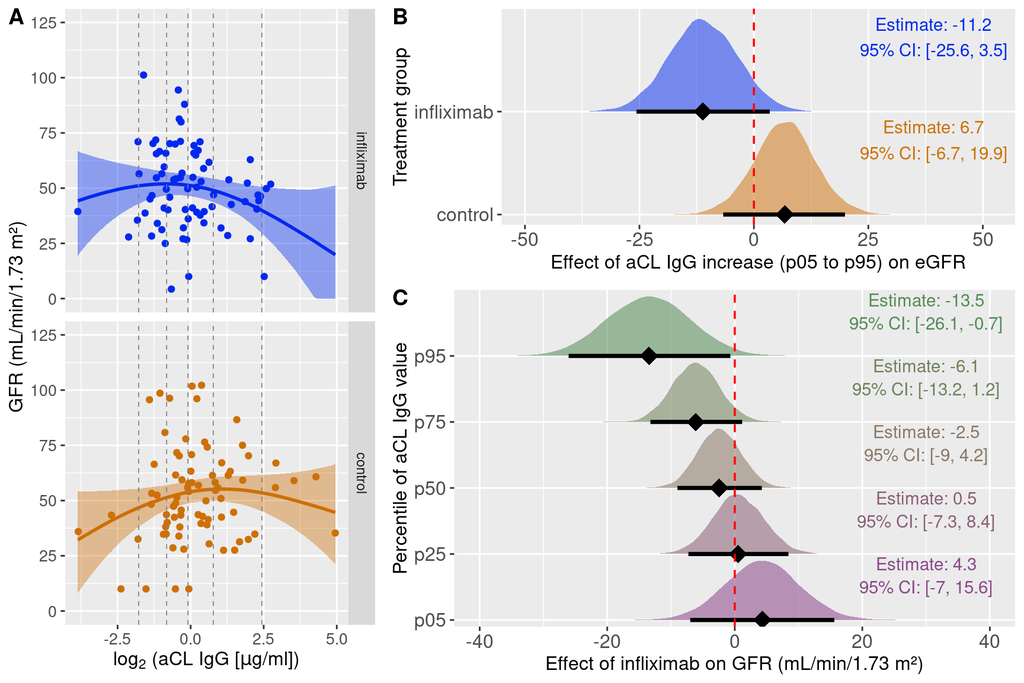

Figure 12: **Anti-cardiolipin IgG modulation of the infliximab effect on estimated glomerula filtration rate (eGFR, both central and local) after excluding patients which were lost to follow-up before 480th day after TX**. (**A**) Predicted eGFR by anti-cardiolipin IgG for infliximab (upper) and control (lower) groups, with covariates held at their sample means. Shaded regions represent 95% credible intervals; dashed lines indicate the 5th, 25th, 50th, 75th, and 95th percentiles of cardiolipin levels. (**B**) Posterior distribution of the estimated change in eGFR when anti-cardiolipin IgG increases from the 5th to the 95th sample percentile. (**C**) Posterior distribution of the effect of infliximab on eGFR across anti-cardiolipin IgG percentiles. Results are from a multivariable Bayesian robust regression with B-splines after data restriction.

```r
plotac <- 'sup_figure_8'
path <- "gitignore/figures"


fig <- cowplot::plot_grid(fig_b, fig_c,
  rel_heights = c(0.7, 1),
  labels = c("B", "C"),
  ncol = 1
)

assign(
  plotac,
  cowplot::plot_grid(
    fig_a, fig,
    rel_widths = c(0.6, 1),
    labels = c("A", "")
  )
)

get(plotac)

if (file.exists(paste0(path, "/", plotac)) == FALSE) {
  ggsave(
    path = paste0(path),
    filename = plotac,
    device = "pdf",
    width = 9,
    height = 6
  )
}
```

# 15 Tables and Figures: list with links

## 15.1 Figures

Figure 1: data distributions across groups

Supplementary Figure 1: Spearman correlations

Figure 2: DGF risk according to infliximab:aCL IgG non-linear interaction.

Supplementary Figure 2: DGF risk according to infliximab:aCL IgG non-linear interaction but **after excluding the patients with large aCL IgG values**

Supplementary Figure 3: DGF risk according to infliximab:aCL IgM non-linear interaction

Supplementary Figure 4: eGFR according to infliximab:aCL IgG non-linear interaction

Supplementary Figure 5: eGFR according to infliximab:aCL IgM non-linear interaction

Supplementary Figure 6: eGFR according to infliximab:aCL IgG non-linear interaction but **after excluding the patients with large aCL IgG values**

Supplementary Figure 7: eGFR according to infliximab:aCL IgG non-linear interaction but without imputing eGFR values in cases of graft loss

Supplementary Figure 8: eGFR according to infliximab:aCL IgG non-linear interaction, excluding patients with lost of follow up before 480th day after transplantation

Supplementary Figure 9: infection risk according to infliximab:aPE-ind IgG non-linear interaction.

Supplementary Figure 10: infection risk according to infliximab:aPE-dep IgG non-linear interaction.

## 15.2 Tables

Supplementary Table 1: demography stratified by treatment

Supplementary Table 1 - alternative: demography stratified by treatment and aCL IgG levls (below and at/above median)

Supplementary Table 3: post-transplant outcomes by treatment

Supplementary Table 4: post-transplant outcomes by DGF and treatment

Supplementary Table 5: unadjusted effect of different variables on DGF

Table 1: IFX x nAb non-linear interaction effects based on Bayesian logistic multivariable models

Table 2: IFX x nAb non-linear interaction effects based on Bayesian robust multivariable models modelling eGFR

Supplementary Table 6: unadjusted effect of different variables on eGFR

Supplementary Table 7: mediation analysis

Supplementary Table 9: unadjusted effect of different variables on infection risk

Supplementary Table 10: unadjusted effect of different variables on BKV infection

# 16 Reproducibility

**Open code**

```r
sessionInfo()
## R version 4.4.3 (2025-02-28)
## Platform: x86_64-pc-linux-gnu
## Running under: Ubuntu 22.04.5 LTS
##
## Matrix products: default
## BLAS:   /usr/lib/x86_64-linux-gnu/blas/libblas.so.3.10.0
## LAPACK: /usr/lib/x86_64-linux-gnu/lapack/liblapack.so.3.10.0
##
## locale:
##  [1] LC_CTYPE=en_US.UTF-8       LC_NUMERIC=C
##  [3] LC_TIME=cs_CZ.UTF-8        LC_COLLATE=en_US.UTF-8
##  [5] LC_MONETARY=cs_CZ.UTF-8    LC_MESSAGES=en_US.UTF-8
##  [7] LC_PAPER=cs_CZ.UTF-8       LC_NAME=C
##  [9] LC_ADDRESS=C               LC_TELEPHONE=C
## [11] LC_MEASUREMENT=cs_CZ.UTF-8 LC_IDENTIFICATION=C
##
## time zone: Europe/Prague
## tzcode source: system (glibc)
##
## attached base packages:
## [1] stats     graphics  grDevices utils     datasets  methods   base
##
## other attached packages:
##  [1] bayestestR_0.14.0 mice_3.17.0       ggbeeswarm_0.6.0  quantreg_5.98
##  [5] SparseM_1.81      coxed_0.3.3       survival_3.7-0    rms_6.8-1
##  [9] Hmisc_5.1-3       bayesplot_1.8.1   ggdist_3.3.2      kableExtra_1.4.0
## [13] lubridate_1.9.4   corrplot_0.92     arm_1.12-2        lme4_1.1-35.5
## [17] MASS_7.3-65       janitor_2.2.0     projpred_2.0.2    brms_2.21.0
## [21] Rcpp_1.0.13       glmnet_4.1-8      Matrix_1.7-0      boot_1.3-31
## [25] cowplot_1.1.1     pROC_1.18.0       mgcv_1.9-1        nlme_3.1-168
## [29] openxlsx_4.2.8    flextable_0.9.6   sjPlot_2.8.16     RJDBC_0.2-10
## [33] rJava_1.0-11      DBI_1.2.3         car_3.1-2         carData_3.0-5
## [37] skimr_2.1.5       gtsummary_2.0.2   emmeans_1.10.4    ggpubr_0.4.0
## [41] stringi_1.8.7     forcats_1.0.0     stringr_1.5.1     dplyr_1.1.4
## [45] purrr_1.0.4       readr_2.1.5       tidyr_1.3.1       tibble_3.3.0
## [49] ggplot2_3.5.1     tidyverse_1.3.1
##
## loaded via a namespace (and not attached):
##   [1] fs_1.6.6                matrixStats_1.3.0       httr_1.4.2
##   [4] insight_0.20.2          repr_1.1.7              tools_4.4.3
##   [7] backports_1.5.0         sjlabelled_1.2.0        R6_2.6.1
##  [10] jomo_2.7-3              withr_3.0.2             Brobdingnag_1.2-7
##  [13] prettyunits_1.2.0       gridExtra_2.3           cli_3.6.5
##  [16] textshaping_0.3.6       performance_0.12.2      gt_0.11.0
##  [19] officer_0.6.6           sandwich_3.0-1          labeling_0.4.2
##  [22] sass_0.4.9              mvtnorm_1.1-3           polspline_1.1.25
##  [25] ggridges_0.5.3          askpass_1.1             QuickJSR_1.3.1
##  [28] systemfonts_1.0.4       commonmark_1.9.1        StanHeaders_2.32.10
##  [31] foreign_0.8-90          gfonts_0.2.0            svglite_2.1.3
##  [34] readxl_1.3.1            rstudioapi_0.16.0       httpcode_0.3.0
##  [37] generics_0.1.4          shape_1.4.6             distributional_0.4.0
##  [40] zip_2.2.0               inline_0.3.19           loo_2.4.1
##  [43] abind_1.4-5             lifecycle_1.0.4         multcomp_1.4-18
##  [46] yaml_2.3.10             snakecase_0.11.1        grid_4.4.3
##  [49] promises_1.2.0.1        crayon_1.5.3            mitml_0.4-3
##  [52] lattice_0.22-5          haven_2.4.3             pillar_1.11.0
##  [55] knitr_1.50              estimability_1.5.1      codetools_0.2-19
##  [58] pan_1.6                 glue_1.7.0              V8_4.4.2
##  [61] fontLiberation_0.1.0    data.table_1.15.4       vctrs_0.6.5
##  [64] cellranger_1.1.0        gtable_0.3.0            assertthat_0.2.1
##  [67] datawizard_0.12.2       xfun_0.52               mime_0.12
##  [70] coda_0.19-4             iterators_1.0.14        TH.data_1.1-0
##  [73] fontquiver_0.2.1        rstan_2.32.6            tensorA_0.36.2.1
##  [76] vipor_0.4.5             rpart_4.1.24            colorspace_2.0-2
##  [79] nnet_7.3-20             tidyselect_1.2.1        processx_3.8.4
##  [82] compiler_4.4.3          curl_6.4.0              rvest_1.0.2
##  [85] htmlTable_2.4.0         xml2_1.3.3              fontBitstreamVera_0.1.1
##  [88] posterior_1.6.0         checkmate_2.3.2         scales_1.3.0
##  [91] callr_3.7.6             digest_0.6.37           minqa_1.2.4
##  [94] rmarkdown_2.27          htmltools_0.5.8.1       pkgconfig_2.0.3
##  [97] base64enc_0.1-3         dbplyr_2.1.1            fastmap_1.2.0
## [100] rlang_1.1.6             htmlwidgets_1.6.4       shiny_1.9.1
## [103] farver_2.1.0            zoo_1.8-9               jsonlite_2.0.0
## [106] magrittr_2.0.3          Formula_1.2-4           munsell_0.5.0
## [109] gdtools_0.3.7           plyr_1.8.6              pkgbuild_1.3.1
## [112] parallel_4.4.3          sjmisc_2.8.10           ggeffects_1.7.0
## [115] splines_4.4.3           hms_1.1.3               sjstats_0.19.0
## [118] ps_1.7.7                uuid_1.0-3              ggsignif_0.6.3
## [121] markdown_1.13           reshape2_1.4.4          stats4_4.4.3
## [124] rstantools_2.1.1        crul_1.5.0              reprex_2.0.1
## [127] evaluate_1.0.4          RcppParallel_5.1.8      modelr_0.1.8
## [130] nloptr_2.0.0            tzdb_0.5.0              foreach_1.5.2
## [133] httpuv_1.6.5            MatrixModels_0.5-3      cards_0.2.2
## [136] openssl_1.4.6           cardx_0.2.1             broom_1.0.6
## [139] xtable_1.8-4            rstatix_0.7.0           later_1.3.0
## [142] viridisLite_0.4.0       ragg_1.4.0              beeswarm_0.4.0
## [145] cluster_2.1.8.1         gamm4_0.2-6             timechange_0.3.0
## [148] cmdstanr_0.8.0.9000     bridgesampling_1.1-2
```

## References

[1]

V. Petr, F. Tichanek, S.L. Liu, F. Poppelaars, B. Renner, J. Laskowski, S. Purohit, M. Zhao, D. Jalal, P.S. Heeger, J.M. Thurman, Pretransplant natural antibody levels identify a subset of deceased donor kidney transplant recipients that benefit from infliximab induction, American Journal of Transplantation (2025). https://doi.org/10.1016/j.ajt.2025.06.003.

[2]

R Core Team, R: A language and environment for statistical computing, R Foundation for Statistical Computing, Vienna, Austria, 2024. https://www.R-project.org/.

[3]

S. van Buuren, K. Groothuis-Oudshoorn, Mice: Multivariate imputation by chained equations in r, Journal of Statistical Software 45 (2011) 1–67. https://doi.org/10.18637/jss.v045.i03.

[4]

P.-C. Bürkner, Brms: An r package for bayesian multilevel models using stan, 80 (2017). https://doi.org/10.18637/jss.v080.i01.